# BBC News Classification - Entertainment and Comedy

# Pre-processing

Datasets usually conatains all types of raw data, so we need to format it into a similar structure.We will be dealing with missing and noisy data.Explonary data analaysis is performed on the dataset to remove anomalies, to find patterns by grahical representation.

1. Converting the entire dataset into Lower case.

```python
data = data.apply(lambda x: x.astype(str).str.lower())
data
```

|  | category | headline | authors | link | short_description | date | category_codes1 |
| --- | --- | --- | --- | --- | --- | --- | --- |
| 0 | entertainment | 'walking dead' star's reaction to surprise reu... | bill bradley | https://www.huffingtonpost.com/entry/walking-d... | our poor, poor wittle tickers. | 2017-04-03 | 0.0 |
| 1 | comedy | 5 unique ways to ensure a positive 2014 | joseph parker, contributor\nauthor, digital ma... | https://www.huffingtonpost.com/entry/5-unique-... | the temptation you may have to rob others may ... | 2014-01-01 | 1.0 |
| 3 | entertainment | 'the 20/20 experience' reviews, 'admission,' '... | treye green | https://www.huffingtonpost.com/entry/the-2020-... | justin timberlake ended seven years of musical... | 2013-03-23 | 0.0 |
| 4 | comedy | the care less party | will durst, contributor\ncomic, author, column... | https://www.huffingtonpost.com/entry/the-care-... | first there was romney care, and now we got ob... | 2012-07-14 | 1.0 |
| 5 | entertainment | say goodbye to summer with celebrities in bikinis | lauren zupkus | https://www.huffingtonpost.com/entry/labor-day... | got that summertime sadness right now. | 2015-09-07 | 0.0 |
| ... | ... | ... | ... | ... | ... | ... | ... |
| 7993 | entertainment | naomi watts had to go to david lynch's house t... | matthew jacobs | https://www.huffingtonpost.com/entry/naomi-wat... | she doesn't know much more about the revival t... | 2017-05-19 | 0.0 |
| 7994 | entertainment | 'orange is the new black' star hopes one good ... | sara boboltz | https://www.huffingtonpost.com/entry/orange-is... | "we show so much love to a fictional character... | 2017-06-14 | 0.0 |
| 7995 | entertainment | debbie reynolds reportedly rushed to hospital ... | cavan sieczkowski | https://www.huffingtonpost.com/entry/debbie-re... | she reportedly suffered a stroke at her son's ... | 2016-12-28 | 0.0 |
| 7997 | entertainment | susan sarandon has absolutely 'nothing good to... | julia brucculieri | https://www.huffingtonpost.com/entry/susan-sar... | sarandon addressed allegations of sexual assau... | 2016-05-15 | 0.0 |
| 7998 | entertainment | michael moore on why we should all take donald... | julia brucculieri | https://www.huffingtonpost.com/entry/michael-m... | but we shouldn't be afraid of him. | 2017-01-17 | 0.0 |

5876 rows × 7 columns

## Spiliting the entire Dataset based on Category : 'Entertainment' and 'Comedy'

Spilitting the dataset based on the category Entertainment and then pre-processing it.

```python
df_entertainment = data[data['category'] == 'entertainment']
df_entertainment
```

|  | category | headline | authors | link | short_description | date | category_codes1 |
| --- | --- | --- | --- | --- | --- | --- | --- |
| 0 | entertainment | 'walking dead' star's reaction to surprise reu... | bill bradley | https://www.huffingtonpost.com/entry/walking-d... | our poor, poor wittle tickers. | 2017-04-03 | 0.0 |
| 3 | entertainment | 'the 20/20 experience' reviews, 'admission,' '... | treye green | https://www.huffingtonpost.com/entry/the-2020-... | justin timberlake ended seven years of musical... | 2013-03-23 | 0.0 |
| 5 | entertainment | say goodbye to summer with celebrities in bikinis | lauren zupkus | https://www.huffingtonpost.com/entry/labor-day... | got that summertime sadness right now. | 2015-09-07 | 0.0 |
| 7 | entertainment | arya stark and harry potter just took the best... | e. oliver whitney | https://www.huffingtonpost.com/entry/arya-star... | all men mustâ ï»¿dieï»¿ take selfies with harr... | 2015-07-12 | 0.0 |
| 8 | entertainment | actress tonya cornelisse is out of control! | ilana rapp, contributorwriter, nycastings, "v"... | https://www.huffingtonpost.com/entry/actress-t... | have you heard of tonya cornelisse? say whaaaa... | 2014-10-20 | 0.0 |
| ... | ... | ... | ... | ... | ... | ... | ... |
| 7993 | entertainment | naomi watts had to go to david lynch's house t... | matthew jacobs | https://www.huffingtonpost.com/entry/naomi-wat... | she doesn't know much more about the revival t... | 2017-05-19 | 0.0 |
| 7994 | entertainment | 'orange is the new black' star hopes one good ... | sara boboltz | https://www.huffingtonpost.com/entry/orange-is... | "we show so much love to a fictional character... | 2017-06-14 | 0.0 |
| 7995 | entertainment | debbie reynolds reportedly rushed to hospital ... | cavan sieczkowski | https://www.huffingtonpost.com/entry/debbie-re... | she reportedly suffered a stroke at her son's ... | 2016-12-28 | 0.0 |
| 7997 | entertainment | susan sarandon has absolutely 'nothing good to... | julia brucculieri | https://www.huffingtonpost.com/entry/susan-sar... | sarandon addressed allegations of sexual assau... | 2016-05-15 | 0.0 |
| 7998 | entertainment | michael moore on why we should all take donald... | julia brucculieri | https://www.huffingtonpost.com/entry/michael-m... | but we shouldn't be afraid of him. | 2017-01-17 | 0.0 |

4452 rows × 7 columns

We are popping out ofthe columns we want to exclude from the dataframe they are 'Authors', 'Link'.

```python
df_entertainment.pop('authors')
df_entertainment.pop('link')
```

```
0       https://www.huffingtonpost.com/entry/walking-d...
3       https://www.huffingtonpost.com/entry/the-2020-...
5       https://www.huffingtonpost.com/entry/labor-day...
7       https://www.huffingtonpost.com/entry/arya-star...
8       https://www.huffingtonpost.com/entry/actress-t...
                              ...
7993    https://www.huffingtonpost.com/entry/naomi-wat...
7994    https://www.huffingtonpost.com/entry/orange-is...
7995    https://www.huffingtonpost.com/entry/debbie-re...
7997    https://www.huffingtonpost.com/entry/susan-sar...
7998    https://www.huffingtonpost.com/entry/michael-m...
Name: link, Length: 4452, dtype: object
```

```python
# Converting from dataframe to list, this makes all the 'headlines' across the 'Entertainment' category into into a single list.
df_entertainment['headline'].values.tolist()
```

[output not shown]

[output cut: 946 more lines]

[output not shown]

For the column 'Headline' for the 'Entertainment' Category. We are :  
1. Tokenizing it and converting it into a list. (Tokenization helps creates tokens from large chunk of data,These tokens help in understanding the context or developing the model for the NLP.  
2. Converting into Lower Case. (best pre-processing step to convert all data into the same format).  
3. We are removing punctuations.(punctuations should be removed as it treatsthe text equally)  
4. We are then removing the Stop words.(Stop words removal helps us to focus on the main content of the dataset)

```python
token_entertainment = nltk.word_tokenize(str(df_entertainment['headline'].values.tolist()))
```

```python
tokensEntertainmentLowerCase = [t.lower() for t in token_entertainment]
```

```python
punc_remove_entertainment = [t for t in tokensEntertainmentLowerCase if t.isalnum()]
punc_remove_entertainment
```

[output not shown]

[output cut: 946 more lines]

[output not shown]

```python
removeStopWordsEntertainment = [t for t in punc_remove_entertainment if t not in stopwords.words('english')]
```

Function that helps us find the frequency of the words and the number of times the word is present in our dataset. We are using 'FreqDist' function to find the most frequent words and the number of times its frequency.

```python
#Method to find the freq Dist.
def findFrequencyDistribution(data,number):
    fdist_f = FreqDist(removeStopWordsEntertainment)
    return fdist_f.most_common(number)
```

```python
print(findFrequencyDistribution(removeStopWordsEntertainment,100))
```

```
[('new', 296), ('trump', 237), ('says', 139), ('first', 136), ('season', 112), ('donald', 110), ('kardashian', 106), ('show', 102), ('trailer', 99), ('movie', 90), ('one', 87), ('music', 86), ('dead', 83), ('star', 83), ('swift', 83), ('video', 80), ('film', 75), ('best', 74), ('back', 74), ('taylor…
```

```python
df_entertainment
```

|  | category | headline | short_description | date | category_codes1 |
| --- | --- | --- | --- | --- | --- |
| 0 | entertainment | 'walking dead' star's reaction to surprise reu... | our poor, poor wittle tickers. | 2017-04-03 | 0.0 |
| 3 | entertainment | 'the 20/20 experience' reviews, 'admission,' '... | justin timberlake ended seven years of musical... | 2013-03-23 | 0.0 |
| 5 | entertainment | say goodbye to summer with celebrities in bikinis | got that summertime sadness right now. | 2015-09-07 | 0.0 |
| 7 | entertainment | arya stark and harry potter just took the best... | all men mustâ ï»¿dieï»¿ take selfies with harr... | 2015-07-12 | 0.0 |
| 8 | entertainment | actress tonya cornelisse is out of control! | have you heard of tonya cornelisse? say whaaaa... | 2014-10-20 | 0.0 |
| ... | ... | ... | ... | ... | ... |
| 7993 | entertainment | naomi watts had to go to david lynch's house t... | she doesn't know much more about the revival t... | 2017-05-19 | 0.0 |
| 7994 | entertainment | 'orange is the new black' star hopes one good ... | "we show so much love to a fictional character... | 2017-06-14 | 0.0 |
| 7995 | entertainment | debbie reynolds reportedly rushed to hospital ... | she reportedly suffered a stroke at her son's ... | 2016-12-28 | 0.0 |
| 7997 | entertainment | susan sarandon has absolutely 'nothing good to... | sarandon addressed allegations of sexual assau... | 2016-05-15 | 0.0 |
| 7998 | entertainment | michael moore on why we should all take donald... | but we shouldn't be afraid of him. | 2017-01-17 | 0.0 |

4452 rows × 5 columns

Spilitting the dataset based on the category 'Comedy' .

```python
df_comedy = data[data['category'] == 'comedy']
df_comedy
```

|  | category | headline | authors | link | short_description | date | category_codes1 |
| --- | --- | --- | --- | --- | --- | --- | --- |
| 1 | comedy | 5 unique ways to ensure a positive 2014 | joseph parker, contributor\nauthor, digital ma... | https://www.huffingtonpost.com/entry/5-unique-... | the temptation you may have to rob others may ... | 2014-01-01 | 1.0 |
| 4 | comedy | the care less party | will durst, contributor\ncomic, author, column... | https://www.huffingtonpost.com/entry/the-care-... | first there was romney care, and now we got ob... | 2012-07-14 | 1.0 |
| 6 | comedy | jo-ann fabrics: a forsaken place | brandy ferner, contributor\nbirthing from with... | https://www.huffingtonpost.com/entry/jo-ann-fa... | i quickly chose my fabrics, knowing full well ... | 2013-11-23 | 1.0 |
| 9 | comedy | seth meyers roasts donald trump for not 'winni... | lee moran | https://www.huffingtonpost.com/entry/seth-meye... | or, as some people may call it, losing. | 2017-02-16 | 1.0 |
| 16 | comedy | jimmy kimmel accepts 'tough guy' roy moore's c... | rebecca shapiro | https://www.huffingtonpost.com/entry/jimmy-kim... | the republican senate candidate and former jud... | 2017-12-01 | 1.0 |
| ... | ... | ... | ... | ... | ... | ... | ... |
| 7961 | comedy | the best late night clips of the week (video/p... | matt wilstein, contributor\neditor, gotcha med... | https://www.huffingtonpost.com/entry/the-best-... | letterman, leno and fallon all had the week of... | 2012-10-20 | 1.0 |
| 7966 | comedy | watch the undertaker tombstone some guy in a t... | bill bradley | https://www.huffingtonpost.com/entry/watch-the... | he dead. | 2015-11-12 | 1.0 |
| 7984 | comedy | zac efron and seth rogen draw an ungodly amoun... | bill bradley | https://www.huffingtonpost.com/entry/zac-efron... | in this game, everyone's a wiener. | 2016-04-29 | 1.0 |
| 7985 | comedy | john oliver has the answer to britain's brexit... | ed mazza | https://www.huffingtonpost.com/entry/john-oliv... | "it would not even be close to the stupidest t... | 2017-06-12 | 1.0 |
| 7987 | comedy | samantha bee uses sean hannity's own tactics a... | lee moran | https://www.huffingtonpost.com/entry/samantha-... | âhis whole show is just an hour-long list of... | 2018-04-19 | 1.0 |

1424 rows × 7 columns

We are popping out ofthe columns we want to exclude from the dataframe they are 'Authors', 'Link'.

```python
df_comedy.pop('authors')
df_comedy.pop('link')
```

```
1       https://www.huffingtonpost.com/entry/5-unique-...
4       https://www.huffingtonpost.com/entry/the-care-...
6       https://www.huffingtonpost.com/entry/jo-ann-fa...
9       https://www.huffingtonpost.com/entry/seth-meye...
16      https://www.huffingtonpost.com/entry/jimmy-kim...
                              ...
7961    https://www.huffingtonpost.com/entry/the-best-...
7966    https://www.huffingtonpost.com/entry/watch-the...
7984    https://www.huffingtonpost.com/entry/zac-efron...
7985    https://www.huffingtonpost.com/entry/john-oliv...
7987    https://www.huffingtonpost.com/entry/samantha-...
Name: link, Length: 1424, dtype: object
```

```python
# Converting from dataframe to list, this makes all the 'headlines' across the 'Comedy' category into into a single list.
df_comedy['headline'].values.tolist()
```

[output not shown]

[output cut: 946 more lines]

[output not shown]

For the column 'Headline' for the 'Comedy' Category. We are :  
1. Tokenizing it and converting it into a list. (Tokenization helps creates tokens from large chunk of data,These tokens help in understanding the context or developing the model for the NLP.  
2. Converting into Lower Case. (best pre-processing step to convert all data into the same format).  
3. We are removing punctuations.(punctuations should be removed as it treatsthe text equally)  
4. We are then removing the Stop words.(Stop words removal helps us to focus on the main content of the dataset)

```python
 token_comedy = nltk.word_tokenize(str(df_comedy['headline'].values.tolist()))
```

```python
tokenscomedyLowerCase = [t.lower() for t in token_comedy]
```

```python
punc_remove_comedy = [t for t in tokenscomedyLowerCase if t.isalnum()]
punc_remove_comedy
```

[output not shown]

[output cut: 946 more lines]

[output not shown]

```python
removeStopWordscomedy = [t for t in punc_remove_comedy if t not in stopwords.words('english')]
```

Function that helps us find the frequency of the words and the number of times the word is present in our dataset. We are using 'FreqDist' function to find the most frequent words and the number of times its frequency.

```python
def findFrequencyDistribution(data,number):
    fdist_f = FreqDist(removeStopWordscomedy)
    return fdist_f.most_common(number)
```

```python
print(findFrequencyDistribution(removeStopWordsEntertainment,100))
```

```
[('trump', 343), ('donald', 200), ('colbert', 103), ('jimmy', 62), ('kimmel', 54), ('video', 51), ('noah', 49), ('show', 49), ('maher', 47), ('meyers', 46), ('stephen', 46), ('new', 46), ('bill', 45), ('like', 39), ('seth', 38), ('night', 37), ('fallon', 35), ('bee', 34), ('trevor', 33), ('people', …
```

```python
df_comedy
```

|  | category | headline | short_description | date | category_codes1 |
| --- | --- | --- | --- | --- | --- |
| 1 | comedy | 5 unique ways to ensure a positive 2014 | the temptation you may have to rob others may ... | 2014-01-01 | 1.0 |
| 4 | comedy | the care less party | first there was romney care, and now we got ob... | 2012-07-14 | 1.0 |
| 6 | comedy | jo-ann fabrics: a forsaken place | i quickly chose my fabrics, knowing full well ... | 2013-11-23 | 1.0 |
| 9 | comedy | seth meyers roasts donald trump for not 'winni... | or, as some people may call it, losing. | 2017-02-16 | 1.0 |
| 16 | comedy | jimmy kimmel accepts 'tough guy' roy moore's c... | the republican senate candidate and former jud... | 2017-12-01 | 1.0 |
| ... | ... | ... | ... | ... | ... |
| 7961 | comedy | the best late night clips of the week (video/p... | letterman, leno and fallon all had the week of... | 2012-10-20 | 1.0 |
| 7966 | comedy | watch the undertaker tombstone some guy in a t... | he dead. | 2015-11-12 | 1.0 |
| 7984 | comedy | zac efron and seth rogen draw an ungodly amoun... | in this game, everyone's a wiener. | 2016-04-29 | 1.0 |
| 7985 | comedy | john oliver has the answer to britain's brexit... | "it would not even be close to the stupidest t... | 2017-06-12 | 1.0 |
| 7987 | comedy | samantha bee uses sean hannity's own tactics a... | âhis whole show is just an hour-long list of... | 2018-04-19 | 1.0 |

1424 rows × 5 columns

Function that helps us find the average lenght of sentences for every category that is present in our dataset.

```python
#we are defining a function 'get_average_sentence_length', splitting the text to i) Sentences and ii) Words.
# This helps us find the average length of sentences, for each category.
# That would give us an idea about the length of sentences we will be handling in this project.

def get_average_sentence_length(text):
    sentences = text.split(",")
    words = text.split(" ")
    if(sentences[len(sentences)-1]==""):
        average_sentence_length = len(words)/len(sentences)-1
    else:
        average_sentence_length = len(words)/len(sentences)
    return average_sentence_length
```

```python
avgEntertainment = get_average_sentence_length(str(df_entertainment['headline'].values.tolist()))
avgComedy =get_average_sentence_length(str(df_comedy['headline'].values.tolist()))
```

```python
avgEntertainment
```

```
9.175488522102068
```

```python
avgComedy
```

```
9.145420792079207
```

We are plotting a bar graph of the most frequently occurring words in the 'headline' column. Visualising the most frequent words gives us a better idea, of how to play around with the words we have.

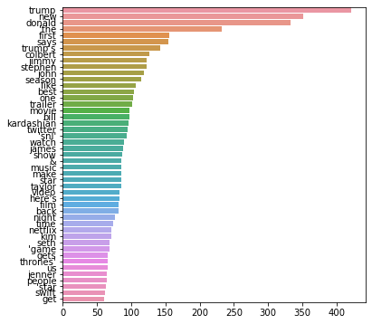

```python
#we are defining a function called 'most_frequent', and the number of times it will occour.
#1. We are checking for the stop words.
#2. We are splitting the data, and adding it into a list.
#3. We are then running a loop, creating counter variable which acts like a
#   container that stores elements as dictionary keys, and their counts are stored as dictionary values.
# 4. We are printing the 100 most common words.

def most_frequent(data):
    stopword=set(stopwords.words('english'))
    data_split= data.str.split()
    data_list=data_split.values.tolist()
    wordpool=[word for j in data_list for word in j]
    counter=Counter(wordpool)
    mostCommon=counter.most_common()
    x, y=[], []
    for word,count in mostCommon[:100]:
        if (word not in stopword):
            x.append(word)
            y.append(count)
    sns.barplot(x=y,y=x)
most_frequent(data['headline'])
```

We are plotting a graph of the most frequently occurring words in the 'Short_description' column.

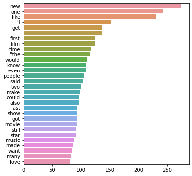

```python
def most_frequent(data):
    stopword=set(stopwords.words('english'))
    data_split= data.str.split()
    data_list=data_split.values.tolist()
    wordpool=[word for j in data_list for word in j]
    counter=Counter(wordpool)
    mostCommon=counter.most_common()
    x, y=[], []
    for word,count in mostCommon[:100]:
        if (word not in stopword):
            x.append(word)
            y.append(count)
    sns.barplot(x=y,y=x)
most_frequent(data['short_description'])
```

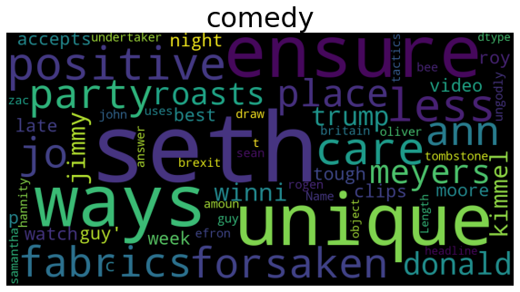

```python
pol = data[data['category'] == 'comedy']
wordcloud = WordCloud(background_color="black", width = 1000, height = 500).generate(''.join(str(pol["headline"])))
plt.figure(figsize=(10,7))
plt.imshow(wordcloud)
plt.title("comedy", fontsize=30)
plt.axis("off")
plt.show()
```

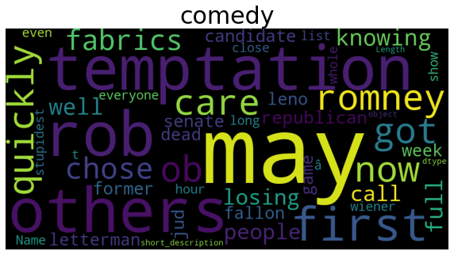

```python
pol = data[data['category'] == 'comedy']
wordcloud = WordCloud(background_color="black", width = 1000, height = 500).generate(''.join(str(pol["short_description"])))
plt.figure(figsize=(10,7))
plt.imshow(wordcloud)
plt.title("comedy", fontsize=30)
plt.axis("off")
plt.show()
```

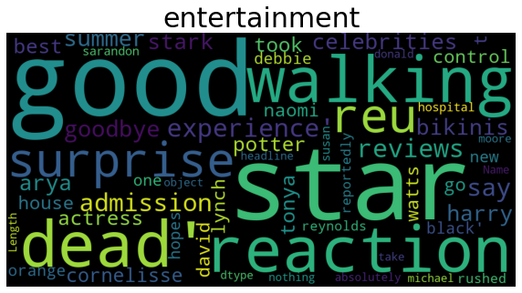

```python
pol = data[data['category'] == 'entertainment']
wordcloud = WordCloud(background_color="black", width = 1000, height = 500).generate(''.join(str(pol["headline"])))
plt.figure(figsize=(10,7))
plt.imshow(wordcloud)
plt.title("entertainment", fontsize=30)
plt.axis("off")
plt.show()
```

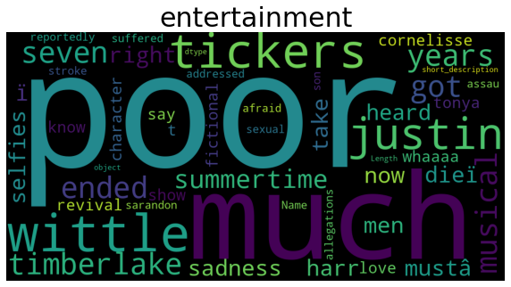

```python
pol = data[data['category'] == 'entertainment']
wordcloud = WordCloud(background_color="black", width = 1000, height = 500).generate(''.join(str(pol["short_description"])))
plt.figure(figsize=(10,7))
plt.imshow(wordcloud)
plt.title("entertainment", fontsize=30)
plt.axis("off")
plt.show()
```

```python
data_fe= data
data_fe
```

|  | category | headline | authors | link | short_description | date | category_codes1 |
| --- | --- | --- | --- | --- | --- | --- | --- |
| 0 | entertainment | 'walking dead' star's reaction to surprise reu... | bill bradley | https://www.huffingtonpost.com/entry/walking-d... | our poor, poor wittle tickers. | 2017-04-03 | 0.0 |
| 1 | comedy | 5 unique ways to ensure a positive 2014 | joseph parker, contributor\nauthor, digital ma... | https://www.huffingtonpost.com/entry/5-unique-... | the temptation you may have to rob others may ... | 2014-01-01 | 1.0 |
| 3 | entertainment | 'the 20/20 experience' reviews, 'admission,' '... | treye green | https://www.huffingtonpost.com/entry/the-2020-... | justin timberlake ended seven years of musical... | 2013-03-23 | 0.0 |
| 4 | comedy | the care less party | will durst, contributor\ncomic, author, column... | https://www.huffingtonpost.com/entry/the-care-... | first there was romney care, and now we got ob... | 2012-07-14 | 1.0 |
| 5 | entertainment | say goodbye to summer with celebrities in bikinis | lauren zupkus | https://www.huffingtonpost.com/entry/labor-day... | got that summertime sadness right now. | 2015-09-07 | 0.0 |
| ... | ... | ... | ... | ... | ... | ... | ... |
| 7993 | entertainment | naomi watts had to go to david lynch's house t... | matthew jacobs | https://www.huffingtonpost.com/entry/naomi-wat... | she doesn't know much more about the revival t... | 2017-05-19 | 0.0 |
| 7994 | entertainment | 'orange is the new black' star hopes one good ... | sara boboltz | https://www.huffingtonpost.com/entry/orange-is... | "we show so much love to a fictional character... | 2017-06-14 | 0.0 |
| 7995 | entertainment | debbie reynolds reportedly rushed to hospital ... | cavan sieczkowski | https://www.huffingtonpost.com/entry/debbie-re... | she reportedly suffered a stroke at her son's ... | 2016-12-28 | 0.0 |
| 7997 | entertainment | susan sarandon has absolutely 'nothing good to... | julia brucculieri | https://www.huffingtonpost.com/entry/susan-sar... | sarandon addressed allegations of sexual assau... | 2016-05-15 | 0.0 |
| 7998 | entertainment | michael moore on why we should all take donald... | julia brucculieri | https://www.huffingtonpost.com/entry/michael-m... | but we shouldn't be afraid of him. | 2017-01-17 | 0.0 |

5876 rows × 7 columns

Here we are analysing other features in the dataset with their relationship with the category(target variable).

```python
# We are using the Tfidf Vectorizer, and passing parameters that will help us with the chi-square analysis.
# some notable paramenters are ngram_range=(1, 2) that indicates that we want to consider unigrams and bigrams.
# min_df= minimum numbers of documents a word must be present in to be kept.

tfidf = TfidfVectorizer(sublinear_tf=True, min_df=5, norm='l2', encoding='latin-1', ngram_range=(1, 2), stop_words='english')

# Remaps the words in the 'headline'column of dataframe.
features = tfidf.fit_transform(data_fe.headline).toarray()

labels = data_fe.category_codes1
```

```python
features.shape
```

```
(5876, 2310)
```

```python
category_to_code.items()
```

```
dict_items([('ENTERTAINMENT', 0.0), ('COMEDY', 1.0)])
```

```python
sorted(category_to_code.items())
```

```
[('COMEDY', 1.0), ('ENTERTAINMENT', 0.0)]
```

```python
# Use chi-square analysis to find corelation between features (importantce of words) and labels(news category)
# We are using the chi-square analysis, as it best fits categorical data, and in our case the 'News categories'
from sklearn.feature_selection import chi2

N = 2

#For each category, we are finding words that are highly corelated to each Category.
# Do chi2 analyses of all items in this category
for category, category_codes1 in sorted(category_to_code.items()):
  features_chi2 = chi2(features, labels == category_codes1 )
  indices = np.argsort(features_chi2[0])         # Sorts the indices of features_chi2[0] - the chi-squared stats of each feature
  feature_names = np.array(tfidf.get_feature_names())[indices]   # Converting indices to feature names
  unigrams = [v for v in feature_names if len(v.split(' ')) == 1]  # List of single word features
  bigrams = [v for v in feature_names if len(v.split(' ')) == 2]    # List for two-word features
  print("# '{}':".format(category))
  print("  . Most correlated unigrams:\n       . {}".format('\n       . '.join(unigrams[-N:])))
  print("  . Most correlated bigrams:\n       . {}".format('\n       . '.join(bigrams[-N:])))
```

```
# 'COMEDY':
  . Most correlated unigrams:
       . hall
       . zings
  . Most correlated bigrams:
       . friends podcast
       . fuller house
# 'ENTERTAINMENT':
  . Most correlated unigrams:
       . hall
       . zings
  . Most correlated bigrams:
       . friends podcast
       . fuller house
```

# Task 2

We are splitting the datset into X ( all columns leaving the target). y contains the target column. This is done to split the dataset, and analyze the X against y (target).

```python
X = data.loc[:,data.columns != 'category']
X.columns
```

```
Index(['headline', 'authors', 'link', 'short_description', 'date',
       'category_codes1'],
      dtype='object')
```

```python
X
```

|  | headline | authors | link | short_description | date | category_codes1 |
| --- | --- | --- | --- | --- | --- | --- |
| 0 | 'walking dead' star's reaction to surprise reu... | bill bradley | https://www.huffingtonpost.com/entry/walking-d... | our poor, poor wittle tickers. | 2017-04-03 | 0.0 |
| 1 | 5 unique ways to ensure a positive 2014 | joseph parker, contributor\nauthor, digital ma... | https://www.huffingtonpost.com/entry/5-unique-... | the temptation you may have to rob others may ... | 2014-01-01 | 1.0 |
| 3 | 'the 20/20 experience' reviews, 'admission,' '... | treye green | https://www.huffingtonpost.com/entry/the-2020-... | justin timberlake ended seven years of musical... | 2013-03-23 | 0.0 |
| 4 | the care less party | will durst, contributor\ncomic, author, column... | https://www.huffingtonpost.com/entry/the-care-... | first there was romney care, and now we got ob... | 2012-07-14 | 1.0 |
| 5 | say goodbye to summer with celebrities in bikinis | lauren zupkus | https://www.huffingtonpost.com/entry/labor-day... | got that summertime sadness right now. | 2015-09-07 | 0.0 |
| ... | ... | ... | ... | ... | ... | ... |
| 7993 | naomi watts had to go to david lynch's house t... | matthew jacobs | https://www.huffingtonpost.com/entry/naomi-wat... | she doesn't know much more about the revival t... | 2017-05-19 | 0.0 |
| 7994 | 'orange is the new black' star hopes one good ... | sara boboltz | https://www.huffingtonpost.com/entry/orange-is... | "we show so much love to a fictional character... | 2017-06-14 | 0.0 |
| 7995 | debbie reynolds reportedly rushed to hospital ... | cavan sieczkowski | https://www.huffingtonpost.com/entry/debbie-re... | she reportedly suffered a stroke at her son's ... | 2016-12-28 | 0.0 |
| 7997 | susan sarandon has absolutely 'nothing good to... | julia brucculieri | https://www.huffingtonpost.com/entry/susan-sar... | sarandon addressed allegations of sexual assau... | 2016-05-15 | 0.0 |
| 7998 | michael moore on why we should all take donald... | julia brucculieri | https://www.huffingtonpost.com/entry/michael-m... | but we shouldn't be afraid of him. | 2017-01-17 | 0.0 |

5876 rows × 6 columns

```python
y = data['category']
y
```

```
0       entertainment
1              comedy
3       entertainment
4              comedy
5       entertainment
            ...
7993    entertainment
7994    entertainment
7995    entertainment
7997    entertainment
7998    entertainment
Name: category, Length: 5876, dtype: object
```

```python
y.isnull().any()
```

```
False
```

We will be splitting the entire dataset into 3 parts:  
1. Train set - this is the dataset that is used to train the model. The model sees and learns from this data. As the train set should be the largest I have taken 55% of the data.  
2. Validation set - It is used to evaluate a given model, butonly for frequent evaluations. Validation set is 25% of the total dataset.  
3. Test set- Sample of data used to provide an unbiased evaluation of a final model fit on a training dataset Test set is 20% of the total dataset.

```python
# We are spliting the frame into X_train_plus_valid and y_train_plus_valid and
# Subsequently into X_train, X_valid, y_train, y_valid.
X_train_plus_valid, X_test, y_train_plus_valid, y_test = train_test_split(X, y, random_state=0, test_size = 0.20, train_size = 0.8)
X_train, X_valid, y_train, y_valid = train_test_split(X_train_plus_valid, y_train_plus_valid, random_state=0, test_size = 0.25/0.8, train_size = 0.55/0.8)
```

```python
X_train_plus_valid
```

|  | headline | authors | link | short_description | date | category_codes1 |
| --- | --- | --- | --- | --- | --- | --- |
| 6178 | kellan lutz & peta: actor saw no problem with ... | madeline boardman | https://www.huffingtonpost.com/entry/kellan-lu... | huffpost entertainment caught up with lutz at ... | 2012-11-17 | 0.0 |
| 7226 | the problem with late night with seth meyers: ... | antonia cereijido, contributorassociate produc... | https://www.huffingtonpost.com/entry/the-probl... | it is easily the best part of the whole show a... | 2014-09-23 | 0.0 |
| 1918 | katy perry's middle-school friend surprises he... | ron dicker | https://www.huffingtonpost.com/entry/katy-perr... | forgive the singer for forgetting her former p... | 2018-03-06 | 0.0 |
| 4851 | 14 steps to harlem: a garland jeffreys premier... | mike ragogna, contributortrafficbeat entertain... | https://www.huffingtonpost.com/entry/14-steps-... | mr: garland, your albums ghost writer, which e... | 2017-04-21 | 0.0 |
| 4692 | jimmy kimmel imagines what trump's presidentia... | lee moran | https://www.huffingtonpost.com/entry/jimmy-kim... | the comedian also has a theory about the newly... | 2018-02-13 | 1.0 |
| ... | ... | ... | ... | ... | ... | ... |
| 6747 | joseph russo plays joe pesci in the film jerse... | ilana rapp, contributorwriter, nycastings, "v"... | https://www.huffingtonpost.com/entry/joseph-ru... | joseph russo is an actor portraying an actor. ... | 2014-06-24 | 0.0 |
| 4399 | maisie williams freaks out over 'game of thron... | bill bradley | https://www.huffingtonpost.com/entry/maisie-wi... | "nothing will prepare you for this." | 2016-08-23 | 0.0 |
| 2211 | melissa manchester still loving the life | dustin fitzharris, contributorworked as associ... | https://www.huffingtonpost.com/entry/melissa-m... | from "midnight blue" to "come in from the rain... | 2015-04-07 | 0.0 |
| 3480 | netflix announces new dave chappelle special i... | andy mcdonald | https://www.huffingtonpost.com/entry/new-dave-... | the stand-upside down? | 2017-11-17 | 0.0 |
| 3657 | olivia wilde cooks in a bikini because clothes... | julia brucculieri | https://www.huffingtonpost.com/entry/olivia-wi... | who needs real clothes in the kitchen, anyway? | 2016-07-17 | 0.0 |

4700 rows × 6 columns

```python
y_train_plus_valid
```

```
6178    entertainment
7226    entertainment
1918    entertainment
4851    entertainment
4692           comedy
            ...
6747    entertainment
4399    entertainment
2211    entertainment
3480    entertainment
3657    entertainment
Name: category, Length: 4700, dtype: object
```

```python
y_train.isnull
```

```
<bound method Series.isnull of 4177           comedy
4129    entertainment
7098           comedy
5536           comedy
7015    entertainment
            ...
7556    entertainment
6348    entertainment
1274    entertainment
5208    entertainment
2398    entertainment
Name: category, Length: 3231, dtype: object>
```

```python
y_valid
```

```
4055    entertainment
81      entertainment
6086           comedy
6362    entertainment
4316    entertainment
            ...
2896    entertainment
3067           comedy
1705    entertainment
5490           comedy
6643    entertainment
Name: category, Length: 1469, dtype: object
```

```python
X_valid
```

|  | headline | authors | link | short_description | date | category_codes1 |
| --- | --- | --- | --- | --- | --- | --- |
| 4055 | disney found its jafar, and you ain't never ha... | bill bradley | https://www.huffingtonpost.com/entry/disney-fo... | tweeters can't get over his "body" of work. | 2017-08-05 | 0.0 |
| 81 | meryl streep recalls that time dustin hoffman ... | cole delbyck | https://www.huffingtonpost.com/entry/meryl-str... | the actress said he was "overstepping" during ... | 2018-01-03 | 0.0 |
| 6086 | jimmy kimmel goes back in time to give baby do... | lee moran | https://www.huffingtonpost.com/entry/jimmy-kim... | for the good of the country. | 2018-04-17 | 1.0 |
| 6362 | somehow, the number of female directors got ev... | jillian capewell | https://www.huffingtonpost.com/entry/in-2016-f... | only 7 percent of the 250 top-grossing films ... | 2017-01-12 | 0.0 |
| 4316 | try to keep calm but k-pop band bts is getting... | kimberly yam | https://www.huffingtonpost.com/entry/bts-burn-... | nope, not calm. not calm at all. | 2018-03-14 | 0.0 |
| ... | ... | ... | ... | ... | ... | ... |
| 2896 | chrissy teigen leaves $1,000 tip for outback s... | ron dicker | https://www.huffingtonpost.com/entry/chrissy-t... | "praise the lord," mikayla scott said. | 2017-11-03 | 0.0 |
| 3067 | stephen colbert shreds don jr. over election f... | ed mazza | https://www.huffingtonpost.com/entry/stephen-c... | "late show" host takes on the president's son. | 2017-11-08 | 1.0 |
| 1705 | sia's new music video stars the next maddie zi... | lily karlin | https://www.huffingtonpost.com/entry/sia-music... | another impressive young star to look out for. | 2015-11-05 | 0.0 |
| 5490 | sam bee presents horrific tales 'coming from i... | andy mcdonald | https://www.huffingtonpost.com/entry/sam-bee-p... | truly horrifying, or horrifyingly true?? | 2017-10-31 | 1.0 |
| 6643 | reese witherspoon better not be lying in crypt... | bill bradley | https://www.huffingtonpost.com/entry/reese-wit... | no more lies! | 2017-05-08 | 0.0 |

1469 rows × 6 columns

We are saving the 'X_train' , 'X_valid' , 'X_test' as 3 sepetrate csv files.

```python
X_train.to_csv('train.csv')
```

```python
X_valid.to_csv('valid.csv')
```

```python
X_test.to_csv('test.csv')
```

## Train Dataset

For the column 'Headline' In the Train dataset. We are :

#### Pre -Processing Steps

1. Tokenizing it and converting it into a list. (Tokenization helps creates tokens from large chunk of data,These tokens help in understanding the context or developing the model for the NLP.  
2. Converting into Lower Case. (best pre-processing step to convert all data into the same format).  
3. We are removing punctuations.(punctuations should be removed as it treatsthe text equally)  
4. We are then removing the Stop words.(Stop words removal helps us to focus on the main content of the dataset)

```python
train_dataset = pd.read_csv("train.csv",header=0)
```

```python
train_dataset = train_dataset.apply(lambda x: x.astype(str).str.lower())
```

Removal of punctuations

```python
train_dataset["headline"] = train_dataset['headline'].str.replace('[^\w\s]','')
```

Removal of stopwords. They are the commonly used words in english language and are unimportant.so we have eliminated it from our column 'headline'.

```python
stop_words = stopwords.words('english')
train_dataset['headline'] = train_dataset['headline'].apply(lambda x: ' '.join([word for word in x.split() if word not in (stop_words)]))
```

```python
train_dataset.replace('NaN','')
```

|  | Unnamed: 0 | headline | authors | link | short_description | date | category_codes1 |
| --- | --- | --- | --- | --- | --- | --- | --- |
| 0 | 4177 | 11 extremely talented people put shame photos | eliza hurwitz | https://www.huffingtonpost.com/entry/11-extrem... | not everyone is lucky enough to have a special... | 2013-06-15 | 1.0 |
| 1 | 4129 | big sick trailer makes leading man kumail nanj... | matthew jacobs | https://www.huffingtonpost.com/entry/the-big-s... | the sweet comedy opens in june. | 2017-05-02 | 0.0 |
| 2 | 7098 | seth meyers chews media gushing trumps speech | rebecca shapiro | https://www.huffingtonpost.com/entry/seth-meye... | "guys, seriously, do you have amnesia?" | 2017-03-02 | 1.0 |
| 3 | 5536 | cargo shorts awareness half week | andy mcdonald | https://www.huffingtonpost.com/entry/its-cargo... | brought to you by huffpost comedy and the othe... | 2016-09-20 | 1.0 |
| 4 | 7015 | catelynn lowell teen mom og heads home treatme... | mary papenfuss | https://www.huffingtonpost.com/entry/teenmom-c... | "so excited for the future," tweets nova's mot... | 2017-12-31 | 0.0 |
| ... | ... | ... | ... | ... | ... | ... | ... |
| 3226 | 7556 | jahmene douglas love never fails tops uk chart... | reuters, reuters | https://www.huffingtonpost.com/entry/jahmene-d... | douglas, 22, was a contestant on a tv talent s... | 2013-07-28 | 0.0 |
| 3227 | 6348 | adele showscases toothless grin cutest throwba... | cole delbyck | https://www.huffingtonpost.com/entry/adele-thr... | d'awwww. | 2015-10-29 | 0.0 |
| 3228 | 1274 | sophia bush says receives pushback voicing pol... | rahel gebreyes | https://www.huffingtonpost.com/entry/sophia-bu... | she doesn't let it stop her. | 2016-03-09 | 0.0 |
| 3229 | 5208 | ariel winter slayed prom disney princess moment | cole delbyck | https://www.huffingtonpost.com/entry/ariel-win... | she's part of our world, all right. | 2016-05-24 | 0.0 |
| 3230 | 2398 | actress candice patton flash dishes set part | ilana rapp, contributorwriter, nycastings, "v"... | https://www.huffingtonpost.com/entry/actress-c... | candice is a talker! her meaty answers forced ... | 2015-04-27 | 0.0 |

3231 rows × 7 columns

```python
train_dataset.drop('authors', axis=1, inplace=True)
train_dataset.drop('link', axis=1, inplace=True)
train_dataset.drop('short_description', axis=1, inplace=True)
train_dataset.drop(['Unnamed: 0'],axis=1, inplace = True)
train_dataset.drop(['date'],axis=1, inplace = True)
```

```python
train_dataset['category_codes1'] = train_dataset['category_codes1'].astype(float)
```

```python
train_dataset['category_codes1'].isnull().any()
```

```
False
```

As we are provided with textual data, it is important to vectorize the data. For NLP to work we need to transform natural language(text or audio) into numeric form.Here we are vectorizing using the tfidf Vectorizer for the train dataset(headline).

Term Frequency — Inverse Document Frequency (TFIDF) is a technique for text vectorization based on the Bag of words (BoW) model. It takes the importance of words in a document into consideration.  
Term frequency-inverse document frequency (tf-idf) gives a measure that takes the importance of a word in consideration depending on how frequently it occurs in a document and a corpus.

```python
tfidf_vector_1 = TfidfVectorizer(analyzer='word',max_features= 4000)
x_tfidf_1 = tfidf_vector_1.fit_transform(train_dataset['headline'])
x_features_1 = pd.DataFrame(x_tfidf_1.toarray())
```

We are splitting the train dataset into Train and test sets. The tests size is 0.2.We will pass vextorized 'x_features_1' as X and train_dataset['category_codes1'] as y.

```python
# splitting the data set to training and testing data set
x_train1, x_test1, y_train1, y_test1 = train_test_split(x_features_1, train_dataset['category_codes1'], test_size=0.2)
```

```python
y_train1.dtypes
```

```
dtype('float64')
```

```python
y_train1.isnull().any()
```

```
False
```

```python
train_dataset['category_codes1']
```

```
0       1.0
1       0.0
2       1.0
3       1.0
4       0.0
       ...
3226    0.0
3227    0.0
3228    0.0
3229    0.0
3230    0.0
Name: category_codes1, Length: 3231, dtype: float64
```

```python
x_train1
```

|  | 0 | 1 | 2 | 3 | 4 | 5 | 6 | 7 | 8 | 9 | ... | 3990 | 3991 | 3992 | 3993 | 3994 | 3995 | 3996 | 3997 | 3998 | 3999 |
| --- | --- | --- | --- | --- | --- | --- | --- | --- | --- | --- | --- | --- | --- | --- | --- | --- | --- | --- | --- | --- | --- |
| 1228 | 0.0 | 0.0 | 0.0 | 0.0 | 0.0 | 0.0 | 0.0 | 0.0 | 0.000000 | 0.0 | ... | 0.0 | 0.0 | 0.0 | 0.0 | 0.0 | 0.0 | 0.0 | 0.0 | 0.0 | 0.0 |
| 2553 | 0.0 | 0.0 | 0.0 | 0.0 | 0.0 | 0.0 | 0.0 | 0.0 | 0.000000 | 0.0 | ... | 0.0 | 0.0 | 0.0 | 0.0 | 0.0 | 0.0 | 0.0 | 0.0 | 0.0 | 0.0 |
| 1438 | 0.0 | 0.0 | 0.0 | 0.0 | 0.0 | 0.0 | 0.0 | 0.0 | 0.000000 | 0.0 | ... | 0.0 | 0.0 | 0.0 | 0.0 | 0.0 | 0.0 | 0.0 | 0.0 | 0.0 | 0.0 |
| 479 | 0.0 | 0.0 | 0.0 | 0.0 | 0.0 | 0.0 | 0.0 | 0.0 | 0.000000 | 0.0 | ... | 0.0 | 0.0 | 0.0 | 0.0 | 0.0 | 0.0 | 0.0 | 0.0 | 0.0 | 0.0 |
| 947 | 0.0 | 0.0 | 0.0 | 0.0 | 0.0 | 0.0 | 0.0 | 0.0 | 0.000000 | 0.0 | ... | 0.0 | 0.0 | 0.0 | 0.0 | 0.0 | 0.0 | 0.0 | 0.0 | 0.0 | 0.0 |
| ... | ... | ... | ... | ... | ... | ... | ... | ... | ... | ... | ... | ... | ... | ... | ... | ... | ... | ... | ... | ... | ... |
| 2505 | 0.0 | 0.0 | 0.0 | 0.0 | 0.0 | 0.0 | 0.0 | 0.0 | 0.000000 | 0.0 | ... | 0.0 | 0.0 | 0.0 | 0.0 | 0.0 | 0.0 | 0.0 | 0.0 | 0.0 | 0.0 |
| 213 | 0.0 | 0.0 | 0.0 | 0.0 | 0.0 | 0.0 | 0.0 | 0.0 | 0.374512 | 0.0 | ... | 0.0 | 0.0 | 0.0 | 0.0 | 0.0 | 0.0 | 0.0 | 0.0 | 0.0 | 0.0 |
| 1332 | 0.0 | 0.0 | 0.0 | 0.0 | 0.0 | 0.0 | 0.0 | 0.0 | 0.000000 | 0.0 | ... | 0.0 | 0.0 | 0.0 | 0.0 | 0.0 | 0.0 | 0.0 | 0.0 | 0.0 | 0.0 |
| 3090 | 0.0 | 0.0 | 0.0 | 0.0 | 0.0 | 0.0 | 0.0 | 0.0 | 0.000000 | 0.0 | ... | 0.0 | 0.0 | 0.0 | 0.0 | 0.0 | 0.0 | 0.0 | 0.0 | 0.0 | 0.0 |
| 311 | 0.0 | 0.0 | 0.0 | 0.0 | 0.0 | 0.0 | 0.0 | 0.0 | 0.000000 | 0.0 | ... | 0.0 | 0.0 | 0.0 | 0.0 | 0.0 | 0.0 | 0.0 | 0.0 | 0.0 | 0.0 |

2584 rows × 4000 columns

```python
y_train1
```

```
1228    1.0
2553    1.0
1438    1.0
479     1.0
947     0.0
       ...
2505    1.0
213     1.0
1332    0.0
3090    0.0
311     0.0
Name: category_codes1, Length: 2584, dtype: float64
```

### Classification Models

We are uisng supervised learning method for this project, where the the computer learns and makes new observations/classifications. Our model will classify, data into two different groups/categoriers.

Random Forest Classifier This classifier is based on the concept of ensemble learning. This is a good classfier as it contains a number of decision trees on various subsets of a given dataset and takes the average to improve the predictive accuracy. This classifier provided a good accuracy score for the train dataset.

We are saving the model using pickle, and then loading the same model to predict the accuracy.Pickle is a python tool best used to save models. This is usally done to save time and load the pre-trained model.

#### Random Forest Classifier

```python
model_rfct1 = RandomForestClassifier()
model_rfct1.fit(x_train1, y_train1)
dump(model_rfct1, open('model_rfct1.pkl', 'wb'))
```

```python
model_rfct1 = pickle.load(open('model_rfct1.pkl', 'rb'))
```

```python
score = model_rfct1.predict(x_test1)
result = accuracy_score(y_test1,score)
print('Test Accuracy:', result)
```

```
Test Accuracy: 0.7990726429675425
```

### Error Analysis using Confusion Matrix

The confusion matrix is a matrix used to determine the performance of the classification models for a given set of train dataset.Errors in the model performance are visualized in the form of a matrix. Confusion matrix run for each classification model, as part of error analysis.

The accuracy score is calculated as the ratio of the number of correct predictions made by the classifier to all number of predictions made by the classifiers.

Accuracy score is the primary metric I will be considering for this project.

```
True Positive(TP)  =  93
False Positive(FP) =  67
True Negative(TN)  =  424
False Negative(FN) =  63
Accuracy of the binary classification = 0.799
```

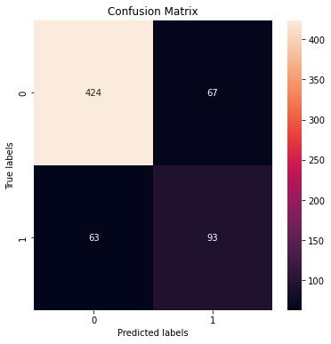

```python
cm=confusion_matrix(y_test1, score )
cm

ax= plt.subplot()
sns.heatmap(cm, annot=True, fmt='g', ax=ax);
ax.set_xlabel('Predicted labels');ax.set_ylabel('True labels');
ax.set_title('Confusion Matrix');
TrueNegative, FalsePositive, FalseNegative, TruePositive = confusion_matrix(y_test1, score).ravel()

print('True Positive(TP)  = ', TruePositive)
print('False Positive(FP) = ', FalsePositive)
print('True Negative(TN)  = ', TrueNegative)
print('False Negative(FN) = ', FalseNegative)

accuracy =  (TruePositive+TrueNegative) /(TruePositive+FalsePositive+TrueNegative+FalseNegative)

print('Accuracy of the binary classification = {:0.3f}'.format(accuracy))
```

#### Decision Tree Classifier

2.Decision Tree Classifier - This classifier has a treelike structure, which is drawn upside down with its root at the top. The main reason for picking this model is ut gave a good accuracy score, and the feature importance is clear and relations can be viwed clearly. this model also provided a good accuracy score for my train Dataset.

```python
model_dtct1 = DecisionTreeClassifier()
model_dtct1.fit(x_train1, y_train1)
dump(model_dtct1, open('model_dtct1.pkl', 'wb'))
```

```python
model_dtct1 = pickle.load(open('model_dtct1.pkl', 'rb'))
```

```python
score = model_dtct1.predict(x_test1)
result = accuracy_score(y_test1,score)
print('Test Accuracy:', result)
```

```
Test Accuracy: 0.7078825347758887
```

```
True Positive(TP)  =  105
False Positive(FP) =  138
True Negative(TN)  =  353
False Negative(FN) =  51
Accuracy of the binary classification = 0.708
```

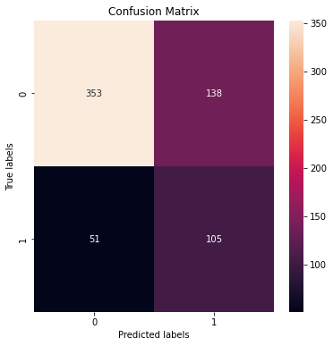

```python
cm=confusion_matrix(y_test1, score)
cm

ax= plt.subplot()
sns.heatmap(cm, annot=True, fmt='g', ax=ax);
ax.set_xlabel('Predicted labels');ax.set_ylabel('True labels');
ax.set_title('Confusion Matrix');
TrueNegative, FalsePositive, FalseNegative, TruePositive = confusion_matrix(y_test1, score).ravel()

print('True Positive(TP)  = ', TruePositive)
print('False Positive(FP) = ', FalsePositive)
print('True Negative(TN)  = ', TrueNegative)
print('False Negative(FN) = ', FalseNegative)

accuracy =  (TruePositive+TrueNegative) /(TruePositive+FalsePositive+TrueNegative+FalseNegative)

print('Accuracy of the binary classification = {:0.3f}'.format(accuracy))
```

## Valid Dataset

We are loading the Valid dataset and pre-porocessing the dataset.

#### Pre -Processing Steps

1. Converting into Lower Case.  
2. We are removing punctuations.  
3. We are then removing the Stop words.  
4. We are popping out ofthe columns we want to exclude from the dataframe they are 'Authors', 'Link'., 'Unnamed: 0'., 'short_description'.

```python
valid_dataset = pd.read_csv("valid.csv",header=0)
```

```python
valid_dataset = valid_dataset.apply(lambda x: x.astype(str).str.lower())
```

Removal of punctuations

```python
valid_dataset["headline"] = valid_dataset['headline'].str.replace('[^\w\s]','')
```

```python
stop_words = stopwords.words('english')
valid_dataset['headline'] = valid_dataset['headline'].apply(lambda x: ' '.join([word for word in x.split() if word not in (stop_words)]))
```

```python
valid_dataset.drop('authors', axis=1, inplace=True)
valid_dataset.drop('link', axis=1, inplace=True)
valid_dataset.drop('date', axis=1, inplace=True)
valid_dataset.drop('short_description', axis=1, inplace=True)
valid_dataset.drop(['Unnamed: 0'],axis=1, inplace = True)
```

```python
valid_dataset['category_codes1'] = valid_dataset['category_codes1'].astype(float)
```

```python
valid_dataset
```

|  | headline | category_codes1 |
| --- | --- | --- |
| 0 | disney found jafar aint never villain like | 0.0 |
| 1 | meryl streep recalls time dustin hoffman slapp... | 0.0 |
| 2 | jimmy kimmel goes back time give baby donald t... | 1.0 |
| 3 | somehow number female directors got even small... | 0.0 |
| 4 | try keep calm kpop band bts getting documentar... | 0.0 |
| ... | ... | ... |
| 1464 | chrissy teigen leaves 1000 tip outback steakho... | 0.0 |
| 1465 | stephen colbert shreds jr election flub turns ... | 1.0 |
| 1466 | sias new music video stars next maddie ziegler | 0.0 |
| 1467 | sam bee presents horrific tales coming inside ... | 1.0 |
| 1468 | reese witherspoon better lying cryptic big lit... | 0.0 |

1469 rows × 2 columns

```python
valid_dataset.count()
```

```
headline           1469
category_codes1    1469
dtype: int64
```

We are vectorizing the valid dataset using the TFIDF vectorizer, then we are splitting the valid dataset into Train and test sets. The tests size is 0.2.We will pass vextorized 'x_features_2' as X and valid_dataset ['category_codes1'] as y.

```python
tfidf_vector_2 = TfidfVectorizer(analyzer='word', max_features=4000)

x_tfidf_2 = tfidf_vector_2.fit_transform(valid_dataset['headline'])

x_features_2 = pd.DataFrame(x_tfidf_2.toarray())
```

```python
# splitting the data set to training and testing data set

x_train2, x_test2, y_train2, y_test2 = train_test_split(x_features_2, valid_dataset['category_codes1'], test_size=0.2)
```

```python
y_test2.dtypes
```

```
dtype('float64')
```

```python
valid_dataset['category_codes1']
```

```
0       0.0
1       0.0
2       1.0
3       0.0
4       0.0
       ...
1464    0.0
1465    1.0
1466    0.0
1467    1.0
1468    0.0
Name: category_codes1, Length: 1469, dtype: float64
```

```python
x_train2
```

|  | 0 | 1 | 2 | 3 | 4 | 5 | 6 | 7 | 8 | 9 | ... | 3990 | 3991 | 3992 | 3993 | 3994 | 3995 | 3996 | 3997 | 3998 | 3999 |
| --- | --- | --- | --- | --- | --- | --- | --- | --- | --- | --- | --- | --- | --- | --- | --- | --- | --- | --- | --- | --- | --- |
| 471 | 0.0 | 0.0 | 0.0 | 0.0 | 0.0 | 0.0 | 0.0 | 0.0 | 0.0 | 0.0 | ... | 0.0 | 0.0 | 0.0 | 0.0 | 0.0 | 0.0 | 0.0 | 0.0 | 0.0 | 0.0 |
| 1297 | 0.0 | 0.0 | 0.0 | 0.0 | 0.0 | 0.0 | 0.0 | 0.0 | 0.0 | 0.0 | ... | 0.0 | 0.0 | 0.0 | 0.0 | 0.0 | 0.0 | 0.0 | 0.0 | 0.0 | 0.0 |
| 1336 | 0.0 | 0.0 | 0.0 | 0.0 | 0.0 | 0.0 | 0.0 | 0.0 | 0.0 | 0.0 | ... | 0.0 | 0.0 | 0.0 | 0.0 | 0.0 | 0.0 | 0.0 | 0.0 | 0.0 | 0.0 |
| 1282 | 0.0 | 0.0 | 0.0 | 0.0 | 0.0 | 0.0 | 0.0 | 0.0 | 0.0 | 0.0 | ... | 0.0 | 0.0 | 0.0 | 0.0 | 0.0 | 0.0 | 0.0 | 0.0 | 0.0 | 0.0 |
| 1325 | 0.0 | 0.0 | 0.0 | 0.0 | 0.0 | 0.0 | 0.0 | 0.0 | 0.0 | 0.0 | ... | 0.0 | 0.0 | 0.0 | 0.0 | 0.0 | 0.0 | 0.0 | 0.0 | 0.0 | 0.0 |
| ... | ... | ... | ... | ... | ... | ... | ... | ... | ... | ... | ... | ... | ... | ... | ... | ... | ... | ... | ... | ... | ... |
| 764 | 0.0 | 0.0 | 0.0 | 0.0 | 0.0 | 0.0 | 0.0 | 0.0 | 0.0 | 0.0 | ... | 0.0 | 0.0 | 0.0 | 0.0 | 0.0 | 0.0 | 0.0 | 0.0 | 0.0 | 0.0 |
| 1399 | 0.0 | 0.0 | 0.0 | 0.0 | 0.0 | 0.0 | 0.0 | 0.0 | 0.0 | 0.0 | ... | 0.0 | 0.0 | 0.0 | 0.0 | 0.0 | 0.0 | 0.0 | 0.0 | 0.0 | 0.0 |
| 403 | 0.0 | 0.0 | 0.0 | 0.0 | 0.0 | 0.0 | 0.0 | 0.0 | 0.0 | 0.0 | ... | 0.0 | 0.0 | 0.0 | 0.0 | 0.0 | 0.0 | 0.0 | 0.0 | 0.0 | 0.0 |
| 946 | 0.0 | 0.0 | 0.0 | 0.0 | 0.0 | 0.0 | 0.0 | 0.0 | 0.0 | 0.0 | ... | 0.0 | 0.0 | 0.0 | 0.0 | 0.0 | 0.0 | 0.0 | 0.0 | 0.0 | 0.0 |
| 925 | 0.0 | 0.0 | 0.0 | 0.0 | 0.0 | 0.0 | 0.0 | 0.0 | 0.0 | 0.0 | ... | 0.0 | 0.0 | 0.0 | 0.0 | 0.0 | 0.0 | 0.0 | 0.0 | 0.0 | 0.0 |

1175 rows × 4000 columns

### Classification Models

The models used for the Train _dataset(Decision tree Classifier and random Forest Classifier) are retrianed using the Valid Dataset's Train and Valid sets . Then the accuracy is calculated.

#### Random Forest Classifier

```python
model_rfct1 = RandomForestClassifier()
model_rfct1.fit(x_train2, y_train2)
dump(model_rfct1, open('model_rfct1.pkl', 'wb'))
```

```python
model_rfct1 = pickle.load(open('model_rfct1.pkl', 'rb'))
```

```python
score = model_rfct1.predict(x_test2)
result = accuracy_score(y_test2,score)
print('Test Accuracy:', result)
```

```
Test Accuracy: 0.7891156462585034
```

### Error Analysis using Confusion Matrix

```
True Positive(TP)  =  27
False Positive(FP) =  13
True Negative(TN)  =  205
False Negative(FN) =  49
Accuracy of the binary classification = 0.789
```

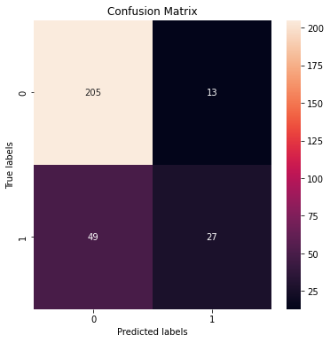

```python
cm=confusion_matrix(y_test2, score)
cm

ax= plt.subplot()
sns.heatmap(cm, annot=True, fmt='g', ax=ax);
ax.set_xlabel('Predicted labels');ax.set_ylabel('True labels');
ax.set_title('Confusion Matrix');
TrueNegative, FalsePositive, FalseNegative, TruePositive = confusion_matrix(y_test2, score).ravel()

print('True Positive(TP)  = ', TruePositive)
print('False Positive(FP) = ', FalsePositive)
print('True Negative(TN)  = ', TrueNegative)
print('False Negative(FN) = ', FalseNegative)

accuracy =  (TruePositive+TrueNegative) /(TruePositive+FalsePositive+TrueNegative+FalseNegative)

print('Accuracy of the binary classification = {:0.3f}'.format(accuracy))
```

#### Decision Tree Classifier

```python
model_dtct1 = DecisionTreeClassifier()
model_dtct1.fit(x_train2, y_train2)
dump(model_dtct1, open('model_dtct1.pkl', 'wb'))
```

```python
model_dtct1 = pickle.load(open('model_dtct1.pkl', 'rb'))
```

```python
score = model_dtct1.predict(x_test2)
result = accuracy_score(y_test2,score)
print('Test Accuracy:', result)
```

```
Test Accuracy: 0.7482993197278912
```

```
True Positive(TP)  =  33
False Positive(FP) =  31
True Negative(TN)  =  187
False Negative(FN) =  43
Accuracy of the binary classification = 0.748
```

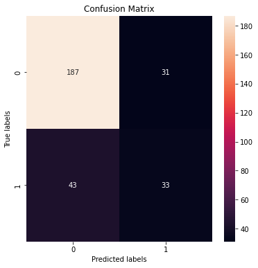

```python
cm=confusion_matrix(y_test2, score)
cm

ax= plt.subplot()
sns.heatmap(cm, annot=True, fmt='g', ax=ax);
ax.set_xlabel('Predicted labels');ax.set_ylabel('True labels');
ax.set_title('Confusion Matrix');
TrueNegative, FalsePositive, FalseNegative, TruePositive = confusion_matrix(y_test2, score).ravel()

print('True Positive(TP)  = ', TruePositive)
print('False Positive(FP) = ', FalsePositive)
print('True Negative(TN)  = ', TrueNegative)
print('False Negative(FN) = ', FalseNegative)

accuracy =  (TruePositive+TrueNegative) /(TruePositive+FalsePositive+TrueNegative+FalseNegative)

print('Accuracy of the binary classification = {:0.3f}'.format(accuracy))
# labels, title and ticks
```

## Train Dataset Modified

The step of lemmatization is one notable change to the dataset. For any NLP project, this is a crucial pre-processing step because it normalizes the data and helps improve our accuracy.

For the Train_dataset we will preprocess the 'headline' column.  
1. Converting into Lower Case.  
2. We are removing punctuations.  
3. We are then removing the Stop words.  
4. We are lemmetizing the headline column, this is a new pre-processing step done to see if there is an increase in the accuracy score.

```python
train_dataset = train_dataset.apply(lambda x: x.astype(str).str.lower())
```

```python
train_dataset["headline"] = train_dataset['headline'].str.replace('[^\w\s]','')
```

```python
stop_words = stopwords.words('english')
train_dataset['headline'] = train_dataset['headline'].apply(lambda x: ' '.join([word for word in x.split() if word not in (stop_words)]))
```

```python
wordnet_lemmatizer = WordNetLemmatizer()
train_dataset['headline'].apply(wordnet_lemmatizer.lemmatize)
```

```
0           11 extremely talented people put shame photos
1       big sick trailer makes leading man kumail nanj...
2           seth meyers chews media gushing trumps speech
3                        cargo shorts awareness half week
4       catelynn lowell teen mom og heads home treatme...
                              ...
3226    jahmene douglas love never fails tops uk chart...
3227    adele showscases toothless grin cutest throwba...
3228    sophia bush says receives pushback voicing pol...
3229      ariel winter slayed prom disney princess moment
3230         actress candice patton flash dishes set part
Name: headline, Length: 3231, dtype: object
```

```python
train_dataset
```

|  | headline | category_codes1 |
| --- | --- | --- |
| 0 | 11 extremely talented people put shame photos | 1.0 |
| 1 | big sick trailer makes leading man kumail nanj... | 0.0 |
| 2 | seth meyers chews media gushing trumps speech | 1.0 |
| 3 | cargo shorts awareness half week | 1.0 |
| 4 | catelynn lowell teen mom og heads home treatme... | 0.0 |
| ... | ... | ... |
| 3226 | jahmene douglas love never fails tops uk chart... | 0.0 |
| 3227 | adele showscases toothless grin cutest throwba... | 0.0 |
| 3228 | sophia bush says receives pushback voicing pol... | 0.0 |
| 3229 | ariel winter slayed prom disney princess moment | 0.0 |
| 3230 | actress candice patton flash dishes set part | 0.0 |

3231 rows × 2 columns

```python
print (train_dataset["category_codes1"].value_counts())
```

```
0.0    2463
1.0     768
Name: category_codes1, dtype: int64
```

```python
train_dataset['category_codes1'] = train_dataset['category_codes1'].astype(float)
```

As we are provided with textual data, it is important to vectorize the data. For NLP to work we need to transform natural language(text or audio) into numeric form.Here we are vectorizing using the tfidf Vectorizer for the train dataset(headline).

We are splitting the train dataset into Train and Test data. We will be running the same algorithms as above, with a new preprocessing step(lemmatising).

```python
tfidf_vector_train = TfidfVectorizer(analyzer='word',max_features=4000)
x_tfidf_train = tfidf_vector_train.fit_transform(train_dataset['headline'])
x_features_train = pd.DataFrame(x_tfidf_train.toarray())
```

```python
# splitting the data set to training and testing data set
x_train1_1, x_test1_1, y_train1_1, y_test1_1 = train_test_split(x_features_train, train_dataset['category_codes1'], test_size=0.2)
```

```python
y_test1_1.dtypes
```

```
dtype('float64')
```

### Classification Models

#### Random Forest Classifier

```python
model_rfct2 = RandomForestClassifier()
model_rfct2.fit(x_train1_1, y_train1_1)
dump(model_rfct2, open('model_rfct2.pkl', 'wb'))
```

```python
model_rfct2 = pickle.load(open('model_rfct2.pkl', 'rb'))
```

```python
score = model_rfct2.predict(x_test1_1)
result = accuracy_score(y_test1_1,score)
print('Test Accuracy:', result)
```

```
Test Accuracy: 0.7836166924265843
```

### Error Analysis using Confusion Matrix

```
True Positive(TP)  =  94
False Positive(FP) =  80
True Negative(TN)  =  413
False Negative(FN) =  60
Accuracy of the binary classification = 0.784
```

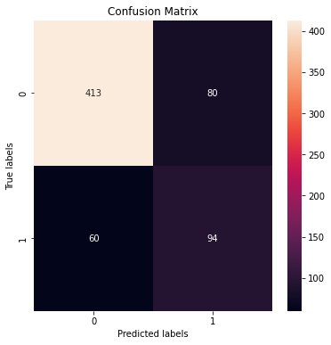

```python
cm=confusion_matrix(y_test1_1, score)
cm

ax= plt.subplot()
sns.heatmap(cm, annot=True, fmt='g', ax=ax);
ax.set_xlabel('Predicted labels');ax.set_ylabel('True labels');
ax.set_title('Confusion Matrix');
TrueNegative, FalsePositive, FalseNegative, TruePositive = confusion_matrix(y_test1_1, score).ravel()

print('True Positive(TP)  = ', TruePositive)
print('False Positive(FP) = ', FalsePositive)
print('True Negative(TN)  = ', TrueNegative)
print('False Negative(FN) = ', FalseNegative)

accuracy =  (TruePositive+TrueNegative) /(TruePositive+FalsePositive+TrueNegative+FalseNegative)

print('Accuracy of the binary classification = {:0.3f}'.format(accuracy))
```

```python
rfc_pred_train = pd.DataFrame(score)
rfc_pred_train.columns = ["Random Forest Classifier"]
rfc_pred_train
```

|  | Random Forest Classifier |
| --- | --- |
| 0 | 0.0 |
| 1 | 0.0 |
| 2 | 0.0 |
| 3 | 0.0 |
| 4 | 0.0 |
| ... | ... |
| 642 | 1.0 |
| 643 | 0.0 |
| 644 | 1.0 |
| 645 | 0.0 |
| 646 | 0.0 |

647 rows × 1 columns

#### Decision Tree Classifier

```python
model_dtct2 = DecisionTreeClassifier()
model_dtct2.fit(x_train1_1, y_train1_1)
dump(model_dtct2, open('model_dtct2.pkl', 'wb'))
```

```python
model_dtct2 = pickle.load(open('model_dtct2.pkl', 'rb'))
```

```python
score = model_dtct2.predict(x_test1_1)
result = accuracy_score(y_test1_1,score)
print('Test Accuracy:', result)
```

```
Test Accuracy: 0.7063369397217929
```

```
True Positive(TP)  =  101
False Positive(FP) =  137
True Negative(TN)  =  356
False Negative(FN) =  53
Accuracy of the binary classification = 0.706
```

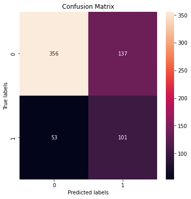

```python
cm=confusion_matrix(y_test1_1, score)
cm

ax= plt.subplot()
sns.heatmap(cm, annot=True, fmt='g', ax=ax);
ax.set_xlabel('Predicted labels');ax.set_ylabel('True labels');
ax.set_title('Confusion Matrix');
TrueNegative, FalsePositive, FalseNegative, TruePositive = confusion_matrix(y_test1_1, score).ravel()

print('True Positive(TP)  = ', TruePositive)
print('False Positive(FP) = ', FalsePositive)
print('True Negative(TN)  = ', TrueNegative)
print('False Negative(FN) = ', FalseNegative)

accuracy =  (TruePositive+TrueNegative) /(TruePositive+FalsePositive+TrueNegative+FalseNegative)

print('Accuracy of the binary classification = {:0.3f}'.format(accuracy))
```

```python
dtc_pred_train = pd.DataFrame(score)
dtc_pred_train.columns = ["Decision Tree Classifier"]
dtc_pred_train
```

|  | Decision Tree Classifier |
| --- | --- |
| 0 | 0.0 |
| 1 | 0.0 |
| 2 | 0.0 |
| 3 | 1.0 |
| 4 | 0.0 |
| ... | ... |
| 642 | 1.0 |
| 643 | 0.0 |
| 644 | 1.0 |
| 645 | 1.0 |
| 646 | 0.0 |

647 rows × 1 columns

```python
dtc_pred_style = dtc_pred_train.style.set_table_attributes("style='display:inline'").set_caption("Decision_Tree")
rfc_pred_style = rfc_pred_train.style.set_table_attributes("style='display:inline'").set_caption("Logistic_Regression")

display_html( dtc_pred_style._repr_html_()+rfc_pred_style._repr_html_() ,raw=True)
```

Decision_Tree

|  | Decision Tree Classifier |
| --- | --- |
| 0 | 0.000000 |
| 1 | 0.000000 |
| 2 | 0.000000 |
| 3 | 1.000000 |
| 4 | 0.000000 |
| 5 | 1.000000 |
| 6 | 1.000000 |
| 7 | 0.000000 |
| 8 | 0.000000 |
| 9 | 1.000000 |
| 10 | 0.000000 |
| 11 | 0.000000 |
| 12 | 0.000000 |
| 13 | 1.000000 |
| 14 | 1.000000 |
| 15 | 0.000000 |
| 16 | 1.000000 |
| 17 | 1.000000 |
| 18 | 1.000000 |
| 19 | 0.000000 |
| 20 | 1.000000 |
| 21 | 0.000000 |
| 22 | 0.000000 |
| 23 | 1.000000 |
| 24 | 1.000000 |
| 25 | 0.000000 |
| 26 | 1.000000 |
| 27 | 0.000000 |
| 28 | 0.000000 |
| 29 | 1.000000 |

[output cut: 617 more lines]

|  | Random Forest Classifier |
| --- | --- |
| 0 | 0.000000 |
| 1 | 0.000000 |
| 2 | 0.000000 |
| 3 | 0.000000 |
| 4 | 0.000000 |
| 5 | 1.000000 |
| 6 | 0.000000 |
| 7 | 0.000000 |
| 8 | 1.000000 |
| 9 | 1.000000 |
| 10 | 0.000000 |
| 11 | 0.000000 |
| 12 | 0.000000 |
| 13 | 1.000000 |
| 14 | 0.000000 |
| 15 | 0.000000 |
| 16 | 0.000000 |
| 17 | 1.000000 |
| 18 | 1.000000 |
| 19 | 0.000000 |
| 20 | 1.000000 |
| 21 | 0.000000 |
| 22 | 0.000000 |
| 23 | 1.000000 |
| 24 | 0.000000 |
| 25 | 0.000000 |
| 26 | 0.000000 |
| 27 | 0.000000 |
| 28 | 0.000000 |
| 29 | 1.000000 |

[output cut: 617 more lines]

## Valid Dataset modified

The step of lemmatization is one notable change to the Valid dataset. For any NLP project, this is a crucial pre-processing step because it normalizes the data and helps improve our accuracy.

For the valid_dataset we will preprocess the 'healine' column.  
1. Converting into Lower Case.  
2. We are removing punctuations.  
3. We are then removing the Stop words.  
4. We are lemmetizing the headline column, this is a new pre-processing step done to see if there is an increase in the accuracy score.

```python
valid_dataset = valid_dataset.apply(lambda x: x.astype(str).str.lower())
```

```python
valid_dataset["headline"] = valid_dataset['headline'].str.replace('[^\w\s]','')
```

```python
stop_words = stopwords.words('english')
valid_dataset['headline'] = valid_dataset['headline'].apply(lambda x: ' '.join([word for word in x.split() if word not in (stop_words)]))
```

```python
wordnet_lemmatizer = WordNetLemmatizer()
valid_dataset['headline'].apply(wordnet_lemmatizer.lemmatize)
```

```
0              disney found jafar aint never villain like
1       meryl streep recalls time dustin hoffman slapp...
2       jimmy kimmel goes back time give baby donald t...
3       somehow number female directors got even small...
4       try keep calm kpop band bts getting documentar...
                              ...
1464    chrissy teigen leaves 1000 tip outback steakho...
1465    stephen colbert shreds jr election flub turns ...
1466       sias new music video stars next maddie ziegler
1467    sam bee presents horrific tales coming inside ...
1468    reese witherspoon better lying cryptic big lit...
Name: headline, Length: 1469, dtype: object
```

```python
valid_dataset['category_codes1'] = valid_dataset['category_codes1'].astype(float)
```

As we are provided with textual data, it is important to vectorize the data. For NLP to work we need to transform natural language(text or audio) into numeric form.Here we are vectorizing using the Tfidf Vectorizer for the train dataset(headline).

We are splitting the valid dataset into Train and Test data. We will be running the same algorithms as above, with a new preprocessing step(lemmatising).

```python
tfidf_vector_valid = TfidfVectorizer(analyzer='word',max_features= 4000)
x_tfidf_valid = tfidf_vector_valid.fit_transform(valid_dataset['headline'])
x_features_valid = pd.DataFrame(x_tfidf_valid.toarray())
```

```python
# splitting the data set to training and testing data set
x_train2_2, x_test2_2, y_train2_2, y_test2_2 = train_test_split(x_features_valid, valid_dataset['category_codes1'], test_size=0.2)
```

```python
y_test2_2.dtypes
```

```
dtype('float64')
```

#### Random Forest Classifier

```python
model_rfct2 = RandomForestClassifier()
model_rfct2.fit(x_train2_2, y_train2_2)
dump(model_rfct2, open('model_rfct2.pkl', 'wb'))
```

```python
model_rfct2 = pickle.load(open('model_rfct2.pkl', 'rb'))
```

```python
score = model_rfct2.predict(x_test2_2)
result = accuracy_score(y_test2_2,score)
print('Test Accuracy:', result)
```

```
Test Accuracy: 0.8197278911564626
```

```
True Positive(TP)  =  21
False Positive(FP) =  5
True Negative(TN)  =  220
False Negative(FN) =  48
Accuracy of the binary classification = 0.820
```

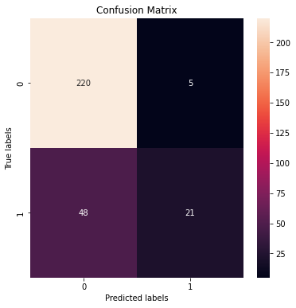

```python
cm=confusion_matrix(y_test2_2, score)
cm

ax= plt.subplot()
sns.heatmap(cm, annot=True, fmt='g', ax=ax);
ax.set_xlabel('Predicted labels');ax.set_ylabel('True labels');
ax.set_title('Confusion Matrix');
TrueNegative, FalsePositive, FalseNegative, TruePositive = confusion_matrix(y_test2_2, score).ravel()

print('True Positive(TP)  = ', TruePositive)
print('False Positive(FP) = ', FalsePositive)
print('True Negative(TN)  = ', TrueNegative)
print('False Negative(FN) = ', FalseNegative)

accuracy =  (TruePositive+TrueNegative) /(TruePositive+FalsePositive+TrueNegative+FalseNegative)

print('Accuracy of the binary classification = {:0.3f}'.format(accuracy))
```

```python
rfc_pred_valid = pd.DataFrame(score)
rfc_pred_valid.columns = ["Random Forest Classifier"]
rfc_pred_valid
```

|  | Random Forest Classifier |
| --- | --- |
| 0 | 0.0 |
| 1 | 0.0 |
| 2 | 0.0 |
| 3 | 1.0 |
| 4 | 0.0 |
| ... | ... |
| 289 | 0.0 |
| 290 | 0.0 |
| 291 | 1.0 |
| 292 | 0.0 |
| 293 | 0.0 |

294 rows × 1 columns

#### Decision Tree Classifier

```python
model_dtct2 = DecisionTreeClassifier()
model_dtct2.fit(x_train2_2, y_train2_2)
dump(model_dtct2, open('model_dtct2.pkl', 'wb'))
```

```python
model_dtct2 = pickle.load(open('model_dtct2.pkl', 'rb'))
```

```python
score = model_dtct2.predict(x_test2_2)
result = accuracy_score(y_test2_2,score)
print('Test Accuracy:', result)
```

```
Test Accuracy: 0.7925170068027211
```

```
True Positive(TP)  =  28
False Positive(FP) =  20
True Negative(TN)  =  205
False Negative(FN) =  41
Accuracy of the binary classification = 0.793
```

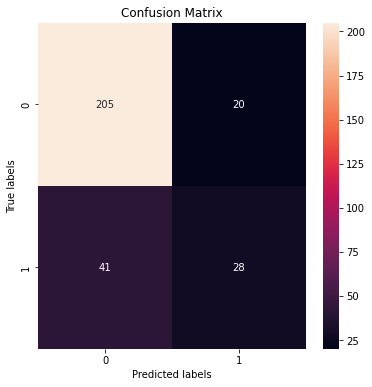

```python
cm=confusion_matrix(y_test2_2, score)
cm

ax= plt.subplot()
sns.heatmap(cm, annot=True, fmt='g', ax=ax);
ax.set_xlabel('Predicted labels');ax.set_ylabel('True labels');
ax.set_title('Confusion Matrix');
TrueNegative, FalsePositive, FalseNegative, TruePositive = confusion_matrix(y_test2_2, score).ravel()

print('True Positive(TP)  = ', TruePositive)
print('False Positive(FP) = ', FalsePositive)
print('True Negative(TN)  = ', TrueNegative)
print('False Negative(FN) = ', FalseNegative)

accuracy =  (TruePositive+TrueNegative) /(TruePositive+FalsePositive+TrueNegative+FalseNegative)

print('Accuracy of the binary classification = {:0.3f}'.format(accuracy))
```

```python
dtc_pred_valid = pd.DataFrame(score)
dtc_pred_valid.columns = ["Decision Tree Classifier"]
dtc_pred_valid
```

|  | Decision Tree Classifier |
| --- | --- |
| 0 | 0.0 |
| 1 | 0.0 |
| 2 | 0.0 |
| 3 | 1.0 |
| 4 | 0.0 |
| ... | ... |
| 289 | 0.0 |
| 290 | 0.0 |
| 291 | 1.0 |
| 292 | 0.0 |
| 293 | 0.0 |

294 rows × 1 columns

```python
rfc1_pred_style = rfc_pred_valid.style.set_table_attributes("style='display:inline'").set_caption("Random_forest")
dtc1_pred_style = dtc_pred_valid.style.set_table_attributes("style='display:inline'").set_caption("Multinomial")

display_html( dtc1_pred_style._repr_html_() + rfc1_pred_style._repr_html_() ,raw=True)
```

|  | Decision Tree Classifier |
| --- | --- |
| 0 | 0.000000 |
| 1 | 0.000000 |
| 2 | 0.000000 |
| 3 | 1.000000 |
| 4 | 0.000000 |
| 5 | 0.000000 |
| 6 | 0.000000 |
| 7 | 0.000000 |
| 8 | 0.000000 |
| 9 | 1.000000 |
| 10 | 0.000000 |
| 11 | 0.000000 |
| 12 | 0.000000 |
| 13 | 0.000000 |
| 14 | 0.000000 |
| 15 | 0.000000 |
| 16 | 0.000000 |
| 17 | 0.000000 |
| 18 | 1.000000 |
| 19 | 1.000000 |
| 20 | 0.000000 |
| 21 | 0.000000 |
| 22 | 0.000000 |
| 23 | 0.000000 |
| 24 | 0.000000 |
| 25 | 1.000000 |
| 26 | 0.000000 |
| 27 | 0.000000 |
| 28 | 0.000000 |
| 29 | 0.000000 |

[output cut: 264 more lines]

Random_forest

|  | Random Forest Classifier |
| --- | --- |
| 0 | 0.000000 |
| 1 | 0.000000 |
| 2 | 0.000000 |
| 3 | 1.000000 |
| 4 | 0.000000 |
| 5 | 0.000000 |
| 6 | 0.000000 |
| 7 | 0.000000 |
| 8 | 0.000000 |
| 9 | 1.000000 |
| 10 | 0.000000 |
| 11 | 0.000000 |
| 12 | 0.000000 |
| 13 | 0.000000 |
| 14 | 0.000000 |
| 15 | 0.000000 |
| 16 | 0.000000 |
| 17 | 0.000000 |
| 18 | 0.000000 |
| 19 | 0.000000 |
| 20 | 0.000000 |
| 21 | 0.000000 |
| 22 | 0.000000 |
| 23 | 0.000000 |
| 24 | 0.000000 |
| 25 | 0.000000 |
| 26 | 0.000000 |
| 27 | 0.000000 |
| 28 | 0.000000 |
| 29 | 0.000000 |

[output cut: 264 more lines]

## Cross Validation

Here we are concatenating the X_train + X_valid datasets, created at the beginning of Task2.

```python
merge_X= pd.concat([X_train,X_valid], axis=0)
```

```python
merge_X
```

|  | headline | authors | link | short_description | date | category_codes1 |
| --- | --- | --- | --- | --- | --- | --- |
| 4177 | 11 extremely talented people who will put you ... | eliza hurwitz | https://www.huffingtonpost.com/entry/11-extrem... | not everyone is lucky enough to have a special... | 2013-06-15 | 1.0 |
| 4129 | 'the big sick' trailer makes a leading man out... | matthew jacobs | https://www.huffingtonpost.com/entry/the-big-s... | the sweet comedy opens in june. | 2017-05-02 | 0.0 |
| 7098 | seth meyers chews out the media for gushing ov... | rebecca shapiro | https://www.huffingtonpost.com/entry/seth-meye... | "guys, seriously, do you have amnesia?" | 2017-03-02 | 1.0 |
| 5536 | it's cargo shorts awareness (half) week! | andy mcdonald | https://www.huffingtonpost.com/entry/its-cargo... | brought to you by huffpost comedy and the othe... | 2016-09-20 | 1.0 |
| 7015 | catelynn lowell of 'teen mom og' heads home af... | mary papenfuss | https://www.huffingtonpost.com/entry/teenmom-c... | "so excited for the future," tweets nova's mot... | 2017-12-31 | 0.0 |
| ... | ... | ... | ... | ... | ... | ... |
| 2896 | chrissy teigen leaves $1,000 tip for outback s... | ron dicker | https://www.huffingtonpost.com/entry/chrissy-t... | "praise the lord," mikayla scott said. | 2017-11-03 | 0.0 |
| 3067 | stephen colbert shreds don jr. over election f... | ed mazza | https://www.huffingtonpost.com/entry/stephen-c... | "late show" host takes on the president's son. | 2017-11-08 | 1.0 |
| 1705 | sia's new music video stars the next maddie zi... | lily karlin | https://www.huffingtonpost.com/entry/sia-music... | another impressive young star to look out for. | 2015-11-05 | 0.0 |
| 5490 | sam bee presents horrific tales 'coming from i... | andy mcdonald | https://www.huffingtonpost.com/entry/sam-bee-p... | truly horrifying, or horrifyingly true?? | 2017-10-31 | 1.0 |
| 6643 | reese witherspoon better not be lying in crypt... | bill bradley | https://www.huffingtonpost.com/entry/reese-wit... | no more lies! | 2017-05-08 | 0.0 |

4700 rows × 6 columns

We are using 'Merge X'

#### Pre -Processing Steps

```python
merge_X.drop('authors', axis=1, inplace=True)
merge_X.drop('link', axis=1, inplace=True)
merge_X.drop('date', axis=1, inplace=True)
merge_X.drop('short_description', axis=1, inplace=True)
merge_X.drop('category_codes1', axis=1, inplace=True)
```

```python
merge_X
```

|  | headline |
| --- | --- |
| 4177 | 11 extremely talented people who will put you ... |
| 4129 | 'the big sick' trailer makes a leading man out... |
| 7098 | seth meyers chews out the media for gushing ov... |
| 5536 | it's cargo shorts awareness (half) week! |
| 7015 | catelynn lowell of 'teen mom og' heads home af... |
| ... | ... |
| 2896 | chrissy teigen leaves $1,000 tip for outback s... |
| 3067 | stephen colbert shreds don jr. over election f... |
| 1705 | sia's new music video stars the next maddie zi... |
| 5490 | sam bee presents horrific tales 'coming from i... |
| 6643 | reese witherspoon better not be lying in crypt... |

4700 rows × 1 columns

```python
merge_X = merge_X.apply(lambda x: x.astype(str).str.lower())
```

```python
merge_X["headline"] = merge_X['headline'].str.replace('[^\w\s]','')
```

```python
stop_words = stopwords.words('english')
merge_X['headline'] = merge_X['headline'].apply(lambda x: ' '.join([word for word in x.split() if word not in (stop_words)]))
```

```python
wordnet_lemmatizer = WordNetLemmatizer()
merge_X['headline'].apply(wordnet_lemmatizer.lemmatize)
```

```
4177        11 extremely talented people put shame photos
4129    big sick trailer makes leading man kumail nanj...
7098        seth meyers chews media gushing trumps speech
5536                     cargo shorts awareness half week
7015    catelynn lowell teen mom og heads home treatme...
                              ...
2896    chrissy teigen leaves 1000 tip outback steakho...
3067    stephen colbert shreds jr election flub turns ...
1705       sias new music video stars next maddie ziegler
5490    sam bee presents horrific tales coming inside ...
6643    reese witherspoon better lying cryptic big lit...
Name: headline, Length: 4700, dtype: object
```

```python
tfidf_vector_tr = TfidfVectorizer(analyzer='word',max_features=4000)
x_tfidf1_tr = tfidf_vector_tr.fit_transform(merge_X['headline'])
x_features_tr = pd.DataFrame(x_tfidf1_tr.toarray())
```

```python
y_train
```

```
4177           comedy
4129    entertainment
7098           comedy
5536           comedy
7015    entertainment
            ...
7556    entertainment
6348    entertainment
1274    entertainment
5208    entertainment
2398    entertainment
Name: category, Length: 3231, dtype: object
```

```python
merge_y= pd.concat([train_dataset['category_codes1'],valid_dataset['category_codes1']], axis=0)
merge_y
```

```
0       1.0
1       0.0
2       1.0
3       1.0
4       0.0
       ...
1464    0.0
1465    1.0
1466    0.0
1467    1.0
1468    0.0
Name: category_codes1, Length: 4700, dtype: float64
```

```python
merge_y.unique()
```

```
array([1., 0.])
```

```python
merge_y.dtypes
```

```
dtype('float64')
```

## K Fold Cross Validation

The best models RFC and DTC are picked after a change (lemmatization) and run on K-fold cross validation. To identify issues like overfitting or selection bias and to provide insight into how the model will generalize to an independent dataset, cross-validation tests the model's tendency to predict new data that was not used in its estimation.

```python
#rfc_t = RandomForestClassifier()
model_rfct2 = pickle.load(open('model_rfct2.pkl', 'rb'))
```

The dataset is divided into 4 'k' groups, each considered as a fold.

```python
folder = KFold(n_splits=4)
```

```python
# Parameters are,the model, vectorized x_merged, merged (y), and the KFold object
results_rfc = cross_val_score(model_rfct2 , x_features_tr, merge_y, cv = folder)
results_rfc
```

```
array([0.77446809, 0.80765957, 0.78978723, 0.79574468])
```

```python
output_rfc = df(results_rfc, columns=["Accuracy_per_fold"])
output_rfc
```

|  | Accuracy_per_fold |
| --- | --- |
| 0 | 0.774468 |
| 1 | 0.807660 |
| 2 | 0.789787 |
| 3 | 0.795745 |

```python
av_val_rfc = output_rfc["Accuracy_per_fold"].mean()*100
print("The average accuracy across folds is {}%".format(av_val_rfc))
```

```
The average accuracy across folds is 79.19148936170214%
```

```python
#dtc_t = DecisionTreeClassifier()
model_dtct2 = pickle.load(open('model_dtct2.pkl', 'rb'))
```

```python
folder = KFold(n_splits=4)
```

```python
results_dtc = cross_val_score(model_dtct2 , x_features_tr, merge_y, cv = folder)# Parameters are, in order - model, X data, labels (y), and the KFold object
results_dtc
```

```
array([0.73021277, 0.72765957, 0.72510638, 0.71319149])
```

```python
output_dtc = df(results_dtc, columns=["Accuracy_per_fold"])
output_dtc
```

|  | Accuracy_per_fold |
| --- | --- |
| 0 | 0.730213 |
| 1 | 0.727660 |
| 2 | 0.725106 |
| 3 | 0.713191 |

```python
av_val_dtc = output_dtc["Accuracy_per_fold"].mean()*100
print("The average accuracy across folds is {}%".format(av_val_dtc))
```

```
The average accuracy across folds is 72.40425531914893%
```

### At the end of K-fold Cross Validation, we have taken Random Forest Classifier with an approximate accuracy of (79 %) as our best Classification Model.

## Test Dataset

For the column 'Headline' for the Test Dataset :  
1. We are tokenizing it and converting it into a list.  
2. Converting into Lower Case.  
3. We are removing punctuations.  
4. We are then removing the Stop words.  
5. We are lemmatizing the column.  
6.We are dropping columns we want to exclude from the dataframe they are 'Authors', 'Date', 'Link'. , 'Unnamed: 0'. ,'Short Description'.

```python
test_dataset = pd.read_csv("test.csv", header=0)
```

```python
test_dataset = test_dataset.apply(lambda x: x.astype(str).str.lower())
```

```python
test_dataset["headline"] = test_dataset['headline'].str.replace('[^\w\s]','')
```

```python
stop_words = stopwords.words('english')
test_dataset['headline'] = test_dataset['headline'].apply(lambda x: ' '.join([word for word in x.split() if word not in (stop_words)]))
```

```python
test_dataset.drop('authors', axis=1, inplace=True)
test_dataset.drop('link', axis=1, inplace=True)
test_dataset.drop('Unnamed: 0', axis=1, inplace=True)
test_dataset.drop('short_description', axis=1, inplace=True)
test_dataset.drop('date', axis=1, inplace=True)
```

```python
test_dataset['category_codes1'] = test_dataset['category_codes1'].astype(float)
```

```python
test_dataset['category_codes1'].dtypes
```

```
dtype('float64')
```

```python
wordnet_lemmatizer = WordNetLemmatizer()
test_dataset['headline'].apply(wordnet_lemmatizer.lemmatize)
```

```
0       heres jay z celebrating 20th anniversary reaso...
1       zac efron corbin bleu lucas grabeel high schoo...
2                     us finale delayed week trump speech
3       john oliver rallies âtimewasters troublemakers...
4       podcast review harmontown epi110 dana carvey t...
                              ...
1171    watch rebel wilson reenact pitch perfect audition
1172             trevor noah donât watch fox news neither
1173    donald trumps snl actually episode curb enthus...
1174             theyre back nbc releases new grace promo
1175    u2 takes aim donald trump white supremacists b...
Name: headline, Length: 1176, dtype: object
```

```python
test_dataset
```

|  | headline | category_codes1 |
| --- | --- | --- |
| 0 | heres jay z celebrating 20th anniversary reaso... | 0.0 |
| 1 | zac efron corbin bleu lucas grabeel high schoo... | 0.0 |
| 2 | us finale delayed week trump speech | 0.0 |
| 3 | john oliver rallies âtimewasters troublemakers... | 1.0 |
| 4 | podcast review harmontown epi110 dana carvey t... | 1.0 |
| ... | ... | ... |
| 1171 | watch rebel wilson reenact pitch perfect audition | 0.0 |
| 1172 | trevor noah donât watch fox news neither | 1.0 |
| 1173 | donald trumps snl actually episode curb enthus... | 1.0 |
| 1174 | theyre back nbc releases new grace promo | 0.0 |
| 1175 | u2 takes aim donald trump white supremacists b... | 0.0 |

1176 rows × 2 columns

We are splitting the test dataset into Train and Test sets. The tests size is 20.We will pass vextorized 'x_features_test' as X and test_dataset['category_codes1'] as y.

```python
tfidf_vector_test = TfidfVectorizer(analyzer='word',max_features=4000)

x_tfidf_test = tfidf_vector_test.fit_transform(test_dataset['headline'])

x_features_test = pd.DataFrame(x_tfidf_test.toarray())
```

```python
X_test_t,X_train_t,y_test_t,y_train_t = train_test_split(x_features_test, test_dataset['category_codes1'], test_size=20)
```

```python
y_test_t.dtypes
```

```
dtype('float64')
```

```python
X_test_t.dtypes
```

```
0       float64
1       float64
2       float64
3       float64
4       float64
         ...
3995    float64
3996    float64
3997    float64
3998    float64
3999    float64
Length: 4000, dtype: object
```

```python
test_dataset['category_codes1']
```

```
0       0.0
1       0.0
2       0.0
3       1.0
4       1.0
       ...
1171    0.0
1172    1.0
1173    1.0
1174    0.0
1175    0.0
Name: category_codes1, Length: 1176, dtype: float64
```

```python
X_test_t
```

|  | 0 | 1 | 2 | 3 | 4 | 5 | 6 | 7 | 8 | 9 | ... | 3990 | 3991 | 3992 | 3993 | 3994 | 3995 | 3996 | 3997 | 3998 | 3999 |
| --- | --- | --- | --- | --- | --- | --- | --- | --- | --- | --- | --- | --- | --- | --- | --- | --- | --- | --- | --- | --- | --- |
| 592 | 0.0 | 0.0 | 0.000000 | 0.0 | 0.0 | 0.0 | 0.0 | 0.0 | 0.0 | 0.0 | ... | 0.0 | 0.0 | 0.0 | 0.0 | 0.0 | 0.0 | 0.0 | 0.0 | 0.0 | 0.0 |
| 546 | 0.0 | 0.0 | 0.000000 | 0.0 | 0.0 | 0.0 | 0.0 | 0.0 | 0.0 | 0.0 | ... | 0.0 | 0.0 | 0.0 | 0.0 | 0.0 | 0.0 | 0.0 | 0.0 | 0.0 | 0.0 |
| 580 | 0.0 | 0.0 | 0.000000 | 0.0 | 0.0 | 0.0 | 0.0 | 0.0 | 0.0 | 0.0 | ... | 0.0 | 0.0 | 0.0 | 0.0 | 0.0 | 0.0 | 0.0 | 0.0 | 0.0 | 0.0 |
| 882 | 0.0 | 0.0 | 0.000000 | 0.0 | 0.0 | 0.0 | 0.0 | 0.0 | 0.0 | 0.0 | ... | 0.0 | 0.0 | 0.0 | 0.0 | 0.0 | 0.0 | 0.0 | 0.0 | 0.0 | 0.0 |
| 471 | 0.0 | 0.0 | 0.386509 | 0.0 | 0.0 | 0.0 | 0.0 | 0.0 | 0.0 | 0.0 | ... | 0.0 | 0.0 | 0.0 | 0.0 | 0.0 | 0.0 | 0.0 | 0.0 | 0.0 | 0.0 |
| ... | ... | ... | ... | ... | ... | ... | ... | ... | ... | ... | ... | ... | ... | ... | ... | ... | ... | ... | ... | ... | ... |
| 307 | 0.0 | 0.0 | 0.000000 | 0.0 | 0.0 | 0.0 | 0.0 | 0.0 | 0.0 | 0.0 | ... | 0.0 | 0.0 | 0.0 | 0.0 | 0.0 | 0.0 | 0.0 | 0.0 | 0.0 | 0.0 |
| 1051 | 0.0 | 0.0 | 0.000000 | 0.0 | 0.0 | 0.0 | 0.0 | 0.0 | 0.0 | 0.0 | ... | 0.0 | 0.0 | 0.0 | 0.0 | 0.0 | 0.0 | 0.0 | 0.0 | 0.0 | 0.0 |
| 945 | 0.0 | 0.0 | 0.000000 | 0.0 | 0.0 | 0.0 | 0.0 | 0.0 | 0.0 | 0.0 | ... | 0.0 | 0.0 | 0.0 | 0.0 | 0.0 | 0.0 | 0.0 | 0.0 | 0.0 | 0.0 |
| 671 | 0.0 | 0.0 | 0.000000 | 0.0 | 0.0 | 0.0 | 0.0 | 0.0 | 0.0 | 0.0 | ... | 0.0 | 0.0 | 0.0 | 0.0 | 0.0 | 0.0 | 0.0 | 0.0 | 0.0 | 0.0 |
| 57 | 0.0 | 0.0 | 0.000000 | 0.0 | 0.0 | 0.0 | 0.0 | 0.0 | 0.0 | 0.0 | ... | 0.0 | 0.0 | 0.0 | 0.0 | 0.0 | 0.0 | 0.0 | 0.0 | 0.0 | 0.0 |

1156 rows × 4000 columns

```python
y_test_t
```

```
592     0.0
546     1.0
580     1.0
882     0.0
471     0.0
       ...
307     0.0
1051    0.0
945     0.0
671     0.0
57      0.0
Name: category_codes1, Length: 1156, dtype: float64
```

```python
model_rfct2 = RandomForestClassifier()
model_rfct2.fit(X_train_t, y_train_t)
dump(model_rfct2, open('model_rfct2.pkl', 'wb'))
```

```python
model_rfct2 = pickle.load(open('model_rfct2.pkl', 'rb'))
```

```python
score = model_rfct2.predict(X_test_t)
result = accuracy_score(y_test_t,score)
print('Test Accuracy:', result)
```

```
Test Accuracy: 0.7612456747404844
```

The Merge X and Merge y are loaded and the split into train and test, with a test size of 20

```python
merge_X
```

|  | headline |
| --- | --- |
| 4177 | 11 extremely talented people put shame photos |
| 4129 | big sick trailer makes leading man kumail nanj... |
| 7098 | seth meyers chews media gushing trumps speech |
| 5536 | cargo shorts awareness half week |
| 7015 | catelynn lowell teen mom og heads home treatme... |
| ... | ... |
| 2896 | chrissy teigen leaves 1000 tip outback steakho... |
| 3067 | stephen colbert shreds jr election flub turns ... |
| 1705 | sias new music video stars next maddie ziegler |
| 5490 | sam bee presents horrific tales coming inside ... |
| 6643 | reese witherspoon better lying cryptic big lit... |

4700 rows × 1 columns

```python
merge_y
```

```
0       1.0
1       0.0
2       1.0
3       1.0
4       0.0
       ...
1464    0.0
1465    1.0
1466    0.0
1467    1.0
1468    0.0
Name: category_codes1, Length: 4700, dtype: float64
```

```python
merge_y.unique()
```

```
array([1., 0.])
```

Merge X is vectorized.

```python
tfidf_vector_mergedx = TfidfVectorizer(analyzer='word',max_features=4000)

x_tfidf_mergedx = tfidf_vector_mergedx.fit_transform(merge_X['headline'])

x_features_mergedx = pd.DataFrame(x_tfidf_mergedx.toarray())
```

```python
x_features_mergedx
```

|  | 0 | 1 | 2 | 3 | 4 | 5 | 6 | 7 | 8 | 9 | ... | 3990 | 3991 | 3992 | 3993 | 3994 | 3995 | 3996 | 3997 | 3998 | 3999 |
| --- | --- | --- | --- | --- | --- | --- | --- | --- | --- | --- | --- | --- | --- | --- | --- | --- | --- | --- | --- | --- | --- |
| 0 | 0.0 | 0.0 | 0.000000 | 0.0 | 0.0 | 0.0 | 0.40991 | 0.0 | 0.0 | 0.0 | ... | 0.0 | 0.0 | 0.0 | 0.0 | 0.0 | 0.0 | 0.0 | 0.0 | 0.0 | 0.0 |
| 1 | 0.0 | 0.0 | 0.000000 | 0.0 | 0.0 | 0.0 | 0.00000 | 0.0 | 0.0 | 0.0 | ... | 0.0 | 0.0 | 0.0 | 0.0 | 0.0 | 0.0 | 0.0 | 0.0 | 0.0 | 0.0 |
| 2 | 0.0 | 0.0 | 0.000000 | 0.0 | 0.0 | 0.0 | 0.00000 | 0.0 | 0.0 | 0.0 | ... | 0.0 | 0.0 | 0.0 | 0.0 | 0.0 | 0.0 | 0.0 | 0.0 | 0.0 | 0.0 |
| 3 | 0.0 | 0.0 | 0.000000 | 0.0 | 0.0 | 0.0 | 0.00000 | 0.0 | 0.0 | 0.0 | ... | 0.0 | 0.0 | 0.0 | 0.0 | 0.0 | 0.0 | 0.0 | 0.0 | 0.0 | 0.0 |
| 4 | 0.0 | 0.0 | 0.000000 | 0.0 | 0.0 | 0.0 | 0.00000 | 0.0 | 0.0 | 0.0 | ... | 0.0 | 0.0 | 0.0 | 0.0 | 0.0 | 0.0 | 0.0 | 0.0 | 0.0 | 0.0 |
| ... | ... | ... | ... | ... | ... | ... | ... | ... | ... | ... | ... | ... | ... | ... | ... | ... | ... | ... | ... | ... | ... |
| 4695 | 0.0 | 0.0 | 0.507461 | 0.0 | 0.0 | 0.0 | 0.00000 | 0.0 | 0.0 | 0.0 | ... | 0.0 | 0.0 | 0.0 | 0.0 | 0.0 | 0.0 | 0.0 | 0.0 | 0.0 | 0.0 |
| 4696 | 0.0 | 0.0 | 0.000000 | 0.0 | 0.0 | 0.0 | 0.00000 | 0.0 | 0.0 | 0.0 | ... | 0.0 | 0.0 | 0.0 | 0.0 | 0.0 | 0.0 | 0.0 | 0.0 | 0.0 | 0.0 |
| 4697 | 0.0 | 0.0 | 0.000000 | 0.0 | 0.0 | 0.0 | 0.00000 | 0.0 | 0.0 | 0.0 | ... | 0.0 | 0.0 | 0.0 | 0.0 | 0.0 | 0.0 | 0.0 | 0.0 | 0.0 | 0.0 |
| 4698 | 0.0 | 0.0 | 0.000000 | 0.0 | 0.0 | 0.0 | 0.00000 | 0.0 | 0.0 | 0.0 | ... | 0.0 | 0.0 | 0.0 | 0.0 | 0.0 | 0.0 | 0.0 | 0.0 | 0.0 | 0.0 |
| 4699 | 0.0 | 0.0 | 0.000000 | 0.0 | 0.0 | 0.0 | 0.00000 | 0.0 | 0.0 | 0.0 | ... | 0.0 | 0.0 | 0.0 | 0.0 | 0.0 | 0.0 | 0.0 | 0.0 | 0.0 | 0.0 |

4700 rows × 4000 columns

```python
X_merged_train,X_merged_test,y_merged_train,y_merged_test = train_test_split(x_features_mergedx,merge_y, test_size= 20)
```

```python
X_merged_train
```

|  | 0 | 1 | 2 | 3 | 4 | 5 | 6 | 7 | 8 | 9 | ... | 3990 | 3991 | 3992 | 3993 | 3994 | 3995 | 3996 | 3997 | 3998 | 3999 |
| --- | --- | --- | --- | --- | --- | --- | --- | --- | --- | --- | --- | --- | --- | --- | --- | --- | --- | --- | --- | --- | --- |
| 1396 | 0.0 | 0.000000 | 0.0 | 0.0 | 0.0 | 0.0 | 0.000000 | 0.0 | 0.0 | 0.0 | ... | 0.0 | 0.0 | 0.0 | 0.0 | 0.0 | 0.0 | 0.0 | 0.0 | 0.0 | 0.0 |
| 3595 | 0.0 | 0.000000 | 0.0 | 0.0 | 0.0 | 0.0 | 0.000000 | 0.0 | 0.0 | 0.0 | ... | 0.0 | 0.0 | 0.0 | 0.0 | 0.0 | 0.0 | 0.0 | 0.0 | 0.0 | 0.0 |
| 216 | 0.0 | 0.000000 | 0.0 | 0.0 | 0.0 | 0.0 | 0.000000 | 0.0 | 0.0 | 0.0 | ... | 0.0 | 0.0 | 0.0 | 0.0 | 0.0 | 0.0 | 0.0 | 0.0 | 0.0 | 0.0 |
| 2657 | 0.0 | 0.000000 | 0.0 | 0.0 | 0.0 | 0.0 | 0.000000 | 0.0 | 0.0 | 0.0 | ... | 0.0 | 0.0 | 0.0 | 0.0 | 0.0 | 0.0 | 0.0 | 0.0 | 0.0 | 0.0 |
| 3962 | 0.0 | 0.000000 | 0.0 | 0.0 | 0.0 | 0.0 | 0.000000 | 0.0 | 0.0 | 0.0 | ... | 0.0 | 0.0 | 0.0 | 0.0 | 0.0 | 0.0 | 0.0 | 0.0 | 0.0 | 0.0 |
| ... | ... | ... | ... | ... | ... | ... | ... | ... | ... | ... | ... | ... | ... | ... | ... | ... | ... | ... | ... | ... | ... |
| 1567 | 0.0 | 0.000000 | 0.0 | 0.0 | 0.0 | 0.0 | 0.500955 | 0.0 | 0.0 | 0.0 | ... | 0.0 | 0.0 | 0.0 | 0.0 | 0.0 | 0.0 | 0.0 | 0.0 | 0.0 | 0.0 |
| 2668 | 0.0 | 0.000000 | 0.0 | 0.0 | 0.0 | 0.0 | 0.000000 | 0.0 | 0.0 | 0.0 | ... | 0.0 | 0.0 | 0.0 | 0.0 | 0.0 | 0.0 | 0.0 | 0.0 | 0.0 | 0.0 |
| 2388 | 0.0 | 0.000000 | 0.0 | 0.0 | 0.0 | 0.0 | 0.000000 | 0.0 | 0.0 | 0.0 | ... | 0.0 | 0.0 | 0.0 | 0.0 | 0.0 | 0.0 | 0.0 | 0.0 | 0.0 | 0.0 |
| 4373 | 0.0 | 0.000000 | 0.0 | 0.0 | 0.0 | 0.0 | 0.000000 | 0.0 | 0.0 | 0.0 | ... | 0.0 | 0.0 | 0.0 | 0.0 | 0.0 | 0.0 | 0.0 | 0.0 | 0.0 | 0.0 |
| 16 | 0.0 | 0.438268 | 0.0 | 0.0 | 0.0 | 0.0 | 0.000000 | 0.0 | 0.0 | 0.0 | ... | 0.0 | 0.0 | 0.0 | 0.0 | 0.0 | 0.0 | 0.0 | 0.0 | 0.0 | 0.0 |

4680 rows × 4000 columns

```python
y_merged_train
```

```
1396    0.0
364     1.0
216     0.0
2657    0.0
731     0.0
       ...
1567    1.0
2668    0.0
2388    0.0
1142    1.0
16      0.0
Name: category_codes1, Length: 4680, dtype: float64
```

### The best model from the previous step is performed with the Merged dataset , providing a great accuracy score for Random Forest Classifier.

```python
model_rfct2 = RandomForestClassifier()
model_rfct2.fit(X_merged_train, y_merged_train)
dump(model_rfct2, open('model_rfct2.pkl', 'wb'))
```

```python
model_rfct2 = pickle.load(open('model_rfct2.pkl', 'rb'))
```

```python
score = model_rfct2.predict(X_merged_test)
result = accuracy_score(y_merged_test,score)
print('Test Accuracy:', result)
```

```
Test Accuracy: 0.8
```

```python
test_dataset
```

|  | headline | category_codes1 |
| --- | --- | --- |
| 0 | heres jay z celebrating 20th anniversary reaso... | 0.0 |
| 1 | zac efron corbin bleu lucas grabeel high schoo... | 0.0 |
| 2 | us finale delayed week trump speech | 0.0 |
| 3 | john oliver rallies âtimewasters troublemakers... | 1.0 |
| 4 | podcast review harmontown epi110 dana carvey t... | 1.0 |
| ... | ... | ... |
| 1171 | watch rebel wilson reenact pitch perfect audition | 0.0 |
| 1172 | trevor noah donât watch fox news neither | 1.0 |
| 1173 | donald trumps snl actually episode curb enthus... | 1.0 |
| 1174 | theyre back nbc releases new grace promo | 0.0 |
| 1175 | u2 takes aim donald trump white supremacists b... | 0.0 |

1176 rows × 2 columns

```python
model_rfct2 = pickle.load(open('model_rfct2.pkl', 'rb'))
```

```python
score = model_rfct2.predict(X_test_t)
result = accuracy_score(y_test_t,score)
print('Test Accuracy:', result)
```

```
Test Accuracy: 0.513840830449827
```